# ROADMAP: Simulated Trial Behaviour (sim09)

Published

September 30, 2026

# About this report

ROADMAP is an adaptive platform trial in prosthetic joint infection. It has four domains and is designed to stop recruiting into a domain when the accumulated evidence is strong enough but continue recruitment into the other domains. Loosely, the four questions are:

- **D1 - Surgical strategy:** is revision surgery (removing and replacing the joint) better than DAIR (debridement and implant retention) for patients with a late-acute infection?
- **D2 - Antibiotic duration:** among patients having a one-stage revision (r1), is a shorter (6-week) course of antibiotics as non-inferior to a 12-week course?
- **D3 - Extended prophylaxis:** among patients having a two-stage revision (r2), does an extra 12 weeks of preventive antibiotics improve outcomes compared with none?
- **D4 - Rifampicin:** does adding rifampicin to the antibiotic regimen improve outcomes?

At each interim analysis, the trial looks at the data collected to date for each of these four questions and asks whether the evidence is strong enough to draw a conclusion. If so, the simulation stops randomising patients to that question and adopts the better (or, for d2, non-inferior) option going forward. Futility stopping is also implemented where stopping occurs due to weak levels of support for addressing the questions of interest.

This report describes the revised simulations results where the simulations are of hypothetical runs of the trial design under a range of assumed “true” states of the world.

Each scenario below assumes a different combination of true effects across the four domains. Most commonly, one domain is set up to have a real effect and the rest are set at zero, so the design’s ability to correctly identify a real effect (and correctly recognise a null one elsewhere) can be checked domain by domain. Some domains are dependent on one another so effects in one result in effects manifesting in another.

This report covers 10 scenario(s):

- All domains log OR zero
- d1 l-OR = 0.5
- d1 l-OR = 0.3
- d4 l-OR = 0.5
- d4 l-OR = 0.3
- d2 l-OR = -0.305 (around -7.5pct)
- d2 l-OR = 0.214 (approx 5pct)
- d3 l-OR = 0.564 (approx 12pct)
- d3 l-OR = 0.75
- Mix d2 l-OR = -0.1, d3 l-OR = 0.7, d4 l-OR = 0.3

The results data are those stored in sim09-13 and have 2500 iterations per scenario.

# How to read the results

For each scenario, we are reporting three things:

1. **Chance of reaching each decision, by interim** - across many simulated trials, what proportion concluded superiority / non-inferiority / futility for each domain, by each interim analysis.
2. **Typical patient numbers** - how many patients are typically enrolled, and how many directly inform each domain’s own comparison, by the time a decision is reached.
3. **Recovered vs. true effect** - whether the trial’s own estimate of each effect (averaged across simulated repeats) tracks the assumed true value.

A full set of the underlying numerical tables (bias, root-mean-square error, coverage, and regimen-level weights) is in the Appendix.

# Simulation configuration

The two tables below describe parts of the design that are the same across every scenario in this report - only the assumed true effects (covered scenario by scenario, below) differ.

Only the late-acute silo that enters into randomised treatment for DAIR versus revision. The other three groups (late-acute patients outside the randomisation window, early infections, and chronic infections) receive whichever surgical strategy their clinician deems appropriate.

Patient population and initial surgical-strategy distribution

| Silo | Share of all patients | D1 randomised? | DAIR | 1-stage revision | 2-stage revision |
| --- | --- | --- | --- | --- | --- |
| Late-acute, randomised | 40% | Yes | 50% | 20% | 30% |
| Late-acute, not randomised | 10% | No (clinician choice) | 50% | 20% | 30% |
| Early infection | 30% | No (clinician choice) | 70% | 15% | 15% |
| Chronic infection | 20% | No (clinician choice) | 20% | 30% | 50% |

## Analysis model

The analysis model includes an intercept, a 4x3 matrix of parameters to address silo and d1 effect and vector terms for d2, d3 and d4. Each of d2, d3 and d4 contains parameters to account for non-randomised treatment/non-reveal along with assignment to the possible randomised treatment strategies.

Treatment effects for d1 contrast late silo dair versus revision participants. However, whereas the response on dair is represented via a single regimen, the revision effects are formed from a mixture of regimens, weighted accordingly (see Appendix for regimens and weights). Implicitly, what is observed in the surgical domain has a dependency on the downstream treatment strategy because d2 and d3 only ever happen for revision patients.

For d2 and d3, deriving the conditional log-odds contrast using weights is overkill, but it gives the same result as referencing the parameter contrasts directly. However, the current design reports standardised marginal effects on both log-odds and risk scales. For the log-odds ratio, this involves averaging the probability over the standardisation population then converting to log-odds and taking the difference. For the risk difference, this involves just averaging the probability over the standardisation population and then doing the contrast.

## Decision rules

For each domain, a decision is reached once the trial is sufficiently confident that the true effect exceeds (or, for futility, falls short of) a pre-specified margin. The decision rules are mutual exclusive to prevent conclusions being simultaneously superior (or ni) and futile. This is not the case for the asymmetric rules, although the chance of it happening even in the asymmetric setup is small.

Decision rules by domain

| Rule | Effect margin (delta) | Confidence required |
| --- | --- | --- |
| D1: Surgical strategy |  |  |
| Superiority | +0.000 | 98% |
| Futility | +0.000 | 50% |
| D2: Antibiotic duration |  |  |
| Non-inferiority | -0.075 | 95% |
| Futility | -0.075 | 50% |
| D3: Extended prophylaxis |  |  |
| Superiority | +0.000 | 98% |
| Futility | +0.000 | 50% |
| D4: Rifampicin |  |  |
| Superiority | +0.000 | 99% |
| Futility | +0.000 | 50% |

# Results by scenario

## All domains log OR zero

**Assumed truth**

None of the four questions has a true effect in this scenario - every comparison is exactly zero. This checks that the design does not falsely declare an effect when there isn’t one.

### Chance of reaching each decision

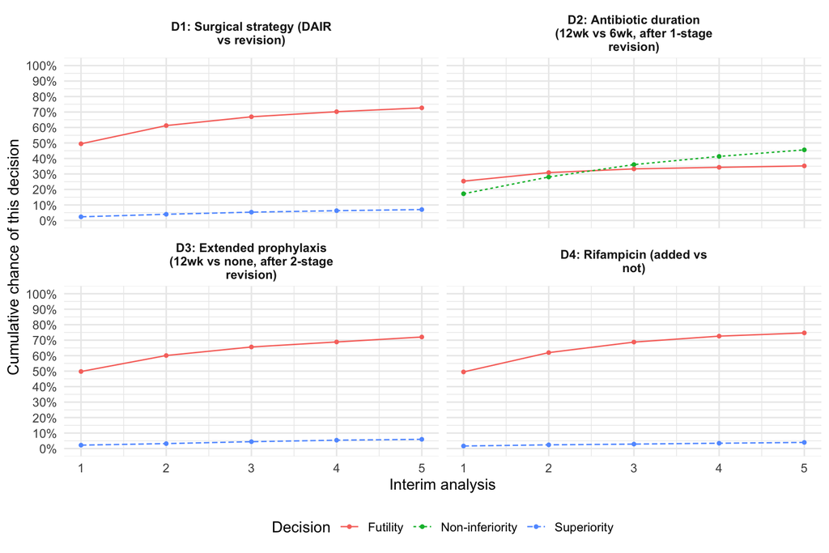

### Typical patient numbers

Patients enrolled by the time a decision is reached

| Domain | Rule | Chance of reaching a decision | Typical no. enrolled at decision | Typical no. informing this decision |
| --- | --- | --- | --- | --- |
| D1: Surgical strategy (DAIR vs revision) | Superiority | 7% | 1223 | 491 |
| D1: Surgical strategy (DAIR vs revision) | Futility | 73% | 795 | 318 |
| D2: Antibiotic duration (12wk vs 6wk, after 1-stage revision) | Non-inferiority | 46% | 1155 | 146 |
| D2: Antibiotic duration (12wk vs 6wk, after 1-stage revision) | Futility | 35% | 741 | 98 |
| D3: Extended prophylaxis (12wk vs none, after 2-stage revision) | Superiority | 6% | 1221 | 216 |
| D3: Extended prophylaxis (12wk vs none, after 2-stage revision) | Futility | 72% | 805 | 152 |
| D4: Rifampicin (added vs not) | Superiority | 4% | 1192 | 833 |
| D4: Rifampicin (added vs not) | Futility | 75% | 807 | 565 |

### Recovered vs. true effect

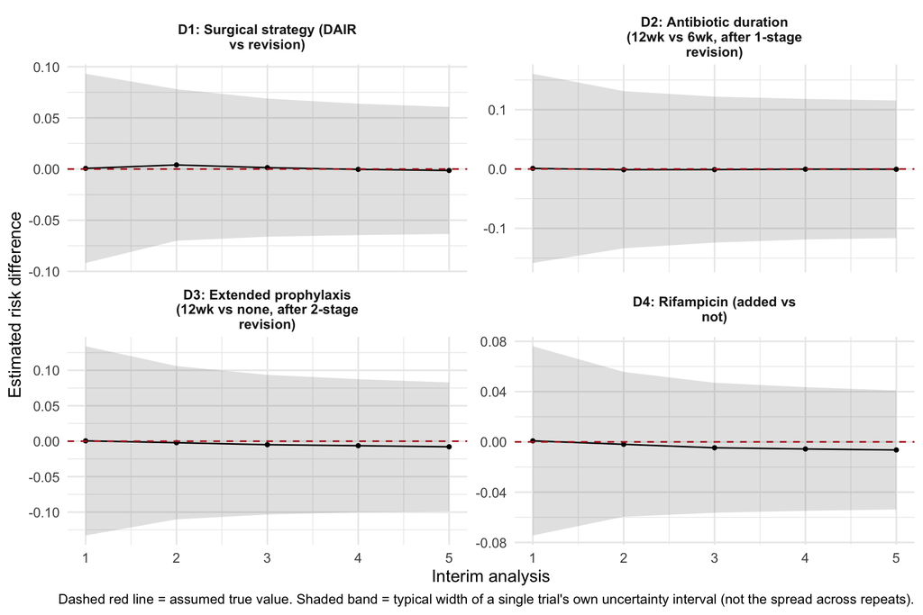

## d1 l-OR = 0.5

**Assumed truth**

**D1: Surgical strategy (DAIR vs revision)** has a true effect of about 11.21 percentage points (risk-difference scale). Any remaining question is set to zero.

### Chance of reaching each decision

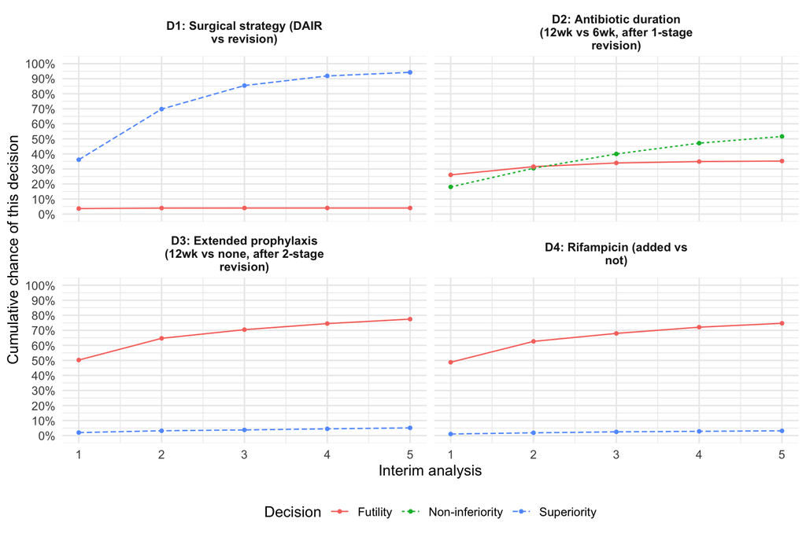

### Typical patient numbers

Patients enrolled by the time a decision is reached

| Domain | Rule | Chance of reaching a decision | Typical no. enrolled at decision | Typical no. informing this decision |
| --- | --- | --- | --- | --- |
| D1: Surgical strategy (DAIR vs revision) | Superiority | 94% | 997 | 399 |
| D1: Surgical strategy (DAIR vs revision) | Futility | 4% | 550 | 221 |
| D2: Antibiotic duration (12wk vs 6wk, after 1-stage revision) | Non-inferiority | 52% | 1186 | 184 |
| D2: Antibiotic duration (12wk vs 6wk, after 1-stage revision) | Futility | 35% | 707 | 104 |
| D3: Extended prophylaxis (12wk vs none, after 2-stage revision) | Superiority | 5% | 1188 | 284 |
| D3: Extended prophylaxis (12wk vs none, after 2-stage revision) | Futility | 77% | 822 | 187 |
| D4: Rifampicin (added vs not) | Superiority | 3% | 1203 | 844 |
| D4: Rifampicin (added vs not) | Futility | 75% | 817 | 572 |

### Recovered vs. true effect

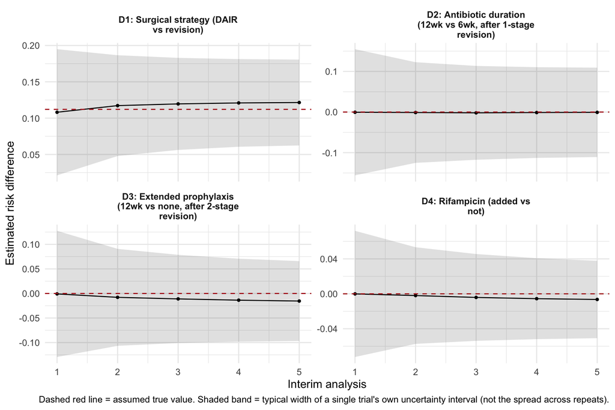

## d1 l-OR = 0.3

**Assumed truth**

**D1: Surgical strategy (DAIR vs revision)** has a true effect of about 6.94 percentage points (risk-difference scale). Any remaining question is set to zero.

### Chance of reaching each decision

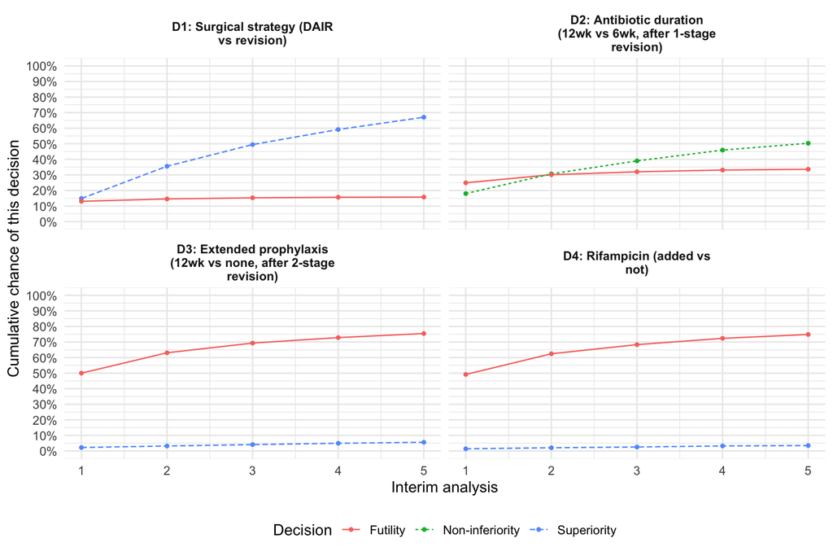

### Typical patient numbers

Patients enrolled by the time a decision is reached

| Domain | Rule | Chance of reaching a decision | Typical no. enrolled at decision | Typical no. informing this decision |
| --- | --- | --- | --- | --- |
| D1: Surgical strategy (DAIR vs revision) | Superiority | 67% | 1314 | 526 |
| D1: Surgical strategy (DAIR vs revision) | Futility | 16% | 643 | 256 |
| D2: Antibiotic duration (12wk vs 6wk, after 1-stage revision) | Non-inferiority | 50% | 1173 | 172 |
| D2: Antibiotic duration (12wk vs 6wk, after 1-stage revision) | Futility | 34% | 712 | 102 |
| D3: Extended prophylaxis (12wk vs none, after 2-stage revision) | Superiority | 6% | 1204 | 263 |
| D3: Extended prophylaxis (12wk vs none, after 2-stage revision) | Futility | 75% | 808 | 175 |
| D4: Rifampicin (added vs not) | Superiority | 3% | 1167 | 819 |
| D4: Rifampicin (added vs not) | Futility | 75% | 815 | 570 |

### Recovered vs. true effect

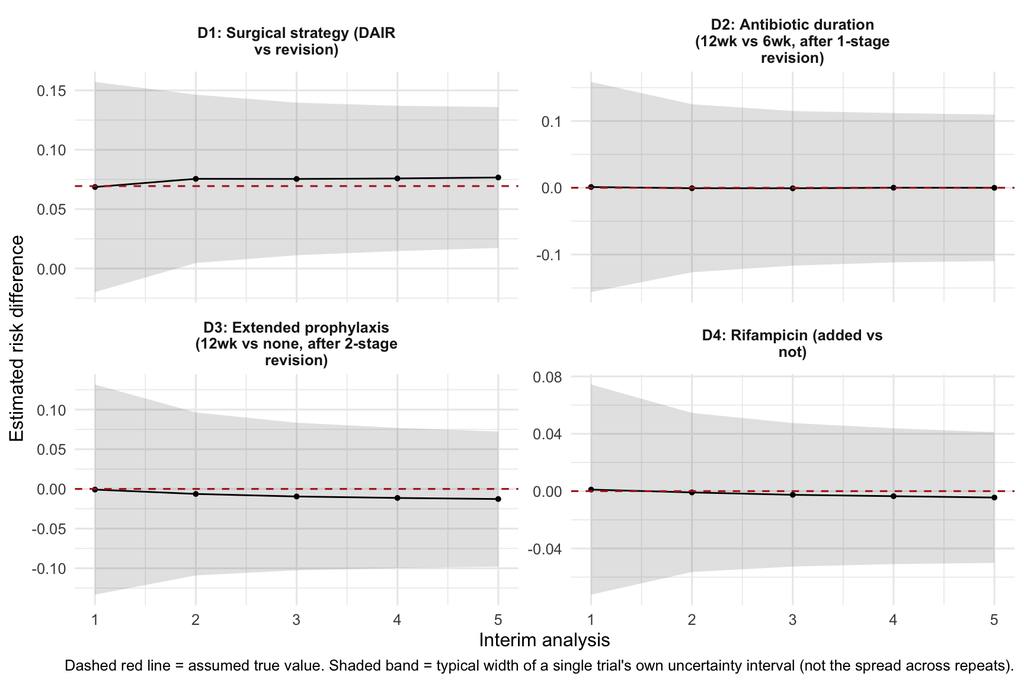

## d4 l-OR = 0.5

**Assumed truth**

**D4: Rifampicin (added vs not)** has a true effect of about 11.21 percentage points (risk-difference scale). Any remaining question is set to zero.

### Chance of reaching each decision

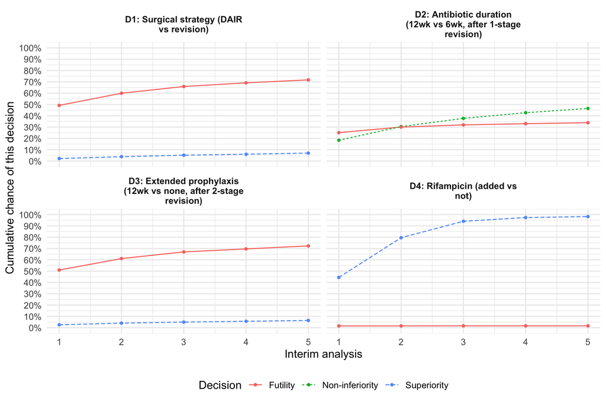

### Typical patient numbers

Patients enrolled by the time a decision is reached

| Domain | Rule | Chance of reaching a decision | Typical no. enrolled at decision | Typical no. informing this decision |
| --- | --- | --- | --- | --- |
| D1: Surgical strategy (DAIR vs revision) | Superiority | 7% | 1271 | 508 |
| D1: Surgical strategy (DAIR vs revision) | Futility | 72% | 798 | 320 |
| D2: Antibiotic duration (12wk vs 6wk, after 1-stage revision) | Non-inferiority | 46% | 1110 | 142 |
| D2: Antibiotic duration (12wk vs 6wk, after 1-stage revision) | Futility | 34% | 728 | 96 |
| D3: Extended prophylaxis (12wk vs none, after 2-stage revision) | Superiority | 6% | 1153 | 220 |
| D3: Extended prophylaxis (12wk vs none, after 2-stage revision) | Futility | 72% | 779 | 149 |
| D4: Rifampicin (added vs not) | Superiority | 98% | 895 | 626 |
| D4: Rifampicin (added vs not) | Futility | 2% | 537 | 375 |

### Recovered vs. true effect

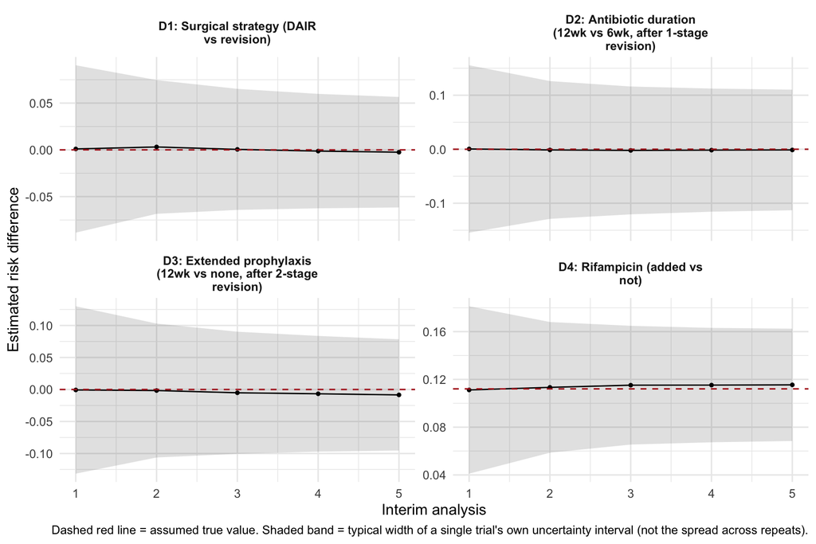

## d4 l-OR = 0.3

**Assumed truth**

**D4: Rifampicin (added vs not)** has a true effect of about 6.94 percentage points (risk-difference scale). Any remaining question is set to zero.

### Chance of reaching each decision

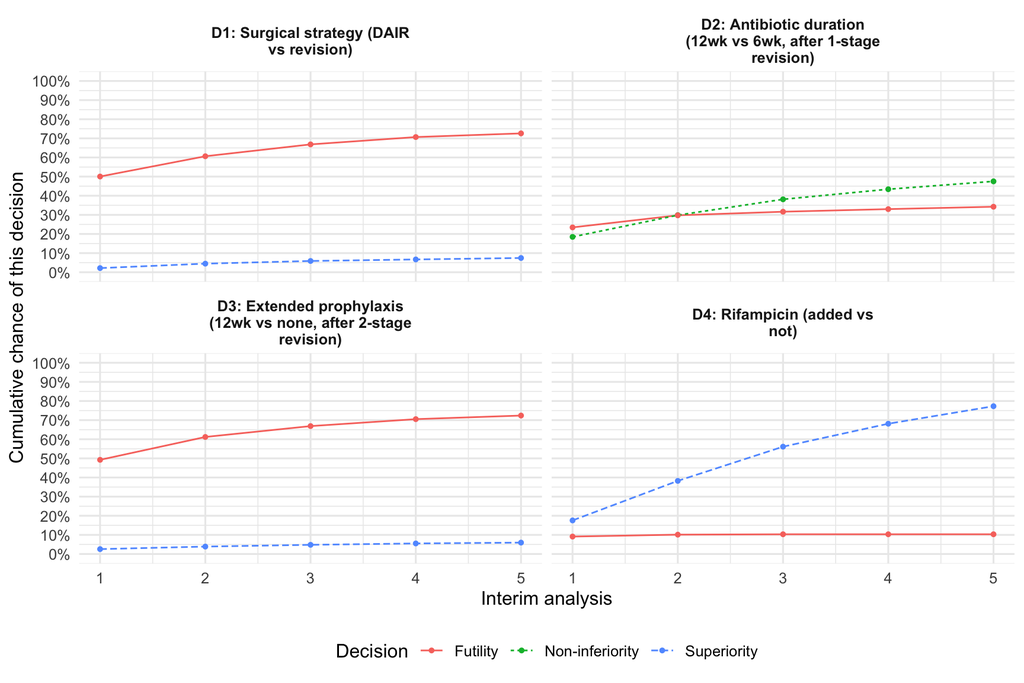

### Typical patient numbers

Patients enrolled by the time a decision is reached

| Domain | Rule | Chance of reaching a decision | Typical no. enrolled at decision | Typical no. informing this decision |
| --- | --- | --- | --- | --- |
| D1: Surgical strategy (DAIR vs revision) | Superiority | 7% | 1210 | 484 |
| D1: Surgical strategy (DAIR vs revision) | Futility | 73% | 791 | 316 |
| D2: Antibiotic duration (12wk vs 6wk, after 1-stage revision) | Non-inferiority | 48% | 1134 | 146 |
| D2: Antibiotic duration (12wk vs 6wk, after 1-stage revision) | Futility | 34% | 779 | 102 |
| D3: Extended prophylaxis (12wk vs none, after 2-stage revision) | Superiority | 6% | 1094 | 198 |
| D3: Extended prophylaxis (12wk vs none, after 2-stage revision) | Futility | 72% | 788 | 150 |
| D4: Rifampicin (added vs not) | Superiority | 77% | 1335 | 934 |
| D4: Rifampicin (added vs not) | Futility | 10% | 568 | 397 |

### Recovered vs. true effect

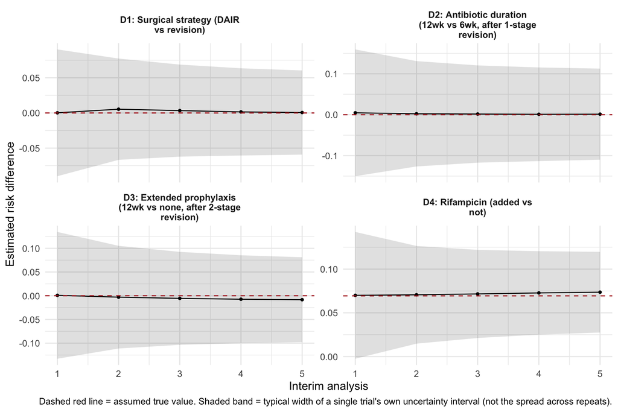

## d2 l-OR = -0.305 (around -7.5pct)

**Assumed truth**

**D1: Surgical strategy (DAIR vs revision)** has a true effect of about -1.05 percentage points (risk-difference scale); **D2: Antibiotic duration (12wk vs 6wk, after 1-stage revision)** has a true effect of about -7.49 percentage points (risk-difference scale). Any remaining question is set to zero.

### Chance of reaching each decision

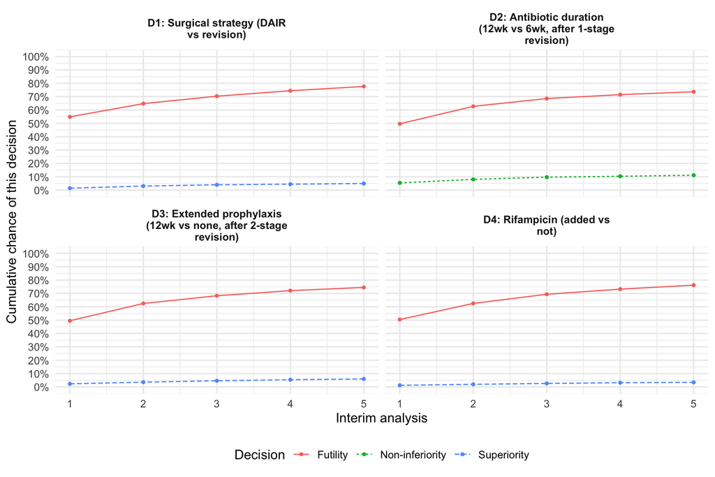

### Typical patient numbers

Patients enrolled by the time a decision is reached

| Domain | Rule | Chance of reaching a decision | Typical no. enrolled at decision | Typical no. informing this decision |
| --- | --- | --- | --- | --- |
| D1: Surgical strategy (DAIR vs revision) | Superiority | 5% | 1198 | 478 |
| D1: Surgical strategy (DAIR vs revision) | Futility | 78% | 797 | 319 |
| D2: Antibiotic duration (12wk vs 6wk, after 1-stage revision) | Non-inferiority | 11% | 1000 | 125 |
| D2: Antibiotic duration (12wk vs 6wk, after 1-stage revision) | Futility | 74% | 786 | 104 |
| D3: Extended prophylaxis (12wk vs none, after 2-stage revision) | Superiority | 6% | 1171 | 203 |
| D3: Extended prophylaxis (12wk vs none, after 2-stage revision) | Futility | 74% | 806 | 152 |
| D4: Rifampicin (added vs not) | Superiority | 3% | 1209 | 847 |
| D4: Rifampicin (added vs not) | Futility | 76% | 823 | 577 |

### Recovered vs. true effect

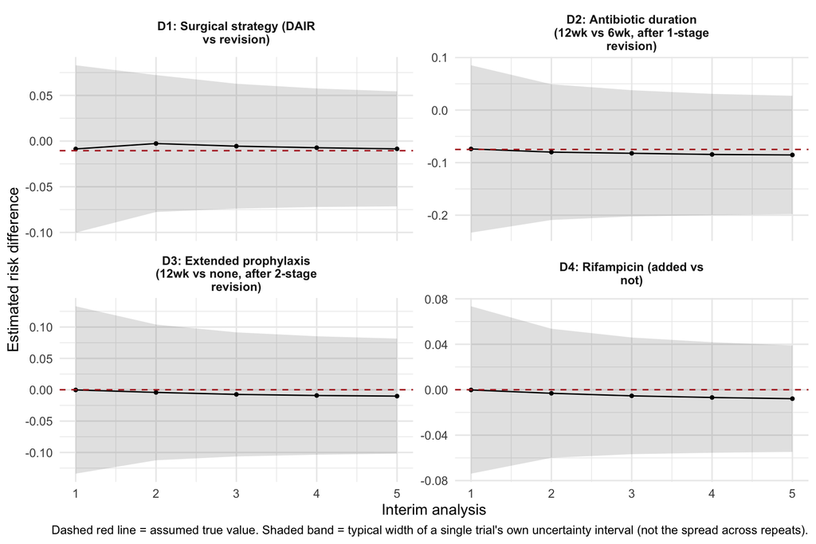

## d2 l-OR = 0.214 (approx 5pct)

**Assumed truth**

**D1: Surgical strategy (DAIR vs revision)** has a true effect of about 0.70 percentage points (risk-difference scale); **D2: Antibiotic duration (12wk vs 6wk, after 1-stage revision)** has a true effect of about 5.01 percentage points (risk-difference scale). Any remaining question is set to zero.

### Chance of reaching each decision

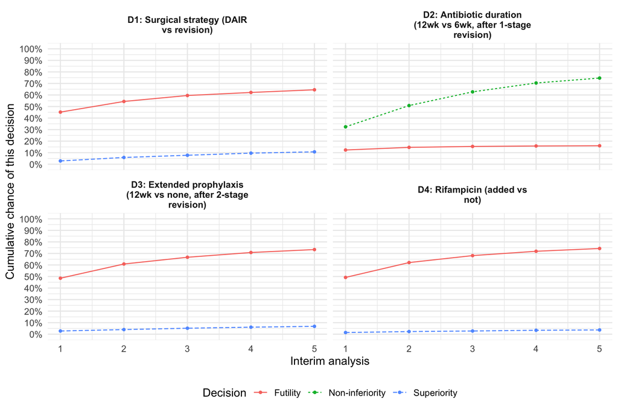

### Typical patient numbers

Patients enrolled by the time a decision is reached

| Domain | Rule | Chance of reaching a decision | Typical no. enrolled at decision | Typical no. informing this decision |
| --- | --- | --- | --- | --- |
| D1: Surgical strategy (DAIR vs revision) | Superiority | 11% | 1285 | 514 |
| D1: Surgical strategy (DAIR vs revision) | Futility | 65% | 785 | 314 |
| D2: Antibiotic duration (12wk vs 6wk, after 1-stage revision) | Non-inferiority | 75% | 1051 | 137 |
| D2: Antibiotic duration (12wk vs 6wk, after 1-stage revision) | Futility | 16% | 684 | 91 |
| D3: Extended prophylaxis (12wk vs none, after 2-stage revision) | Superiority | 7% | 1176 | 225 |
| D3: Extended prophylaxis (12wk vs none, after 2-stage revision) | Futility | 73% | 818 | 156 |
| D4: Rifampicin (added vs not) | Superiority | 4% | 1158 | 809 |
| D4: Rifampicin (added vs not) | Futility | 74% | 809 | 566 |

### Recovered vs. true effect

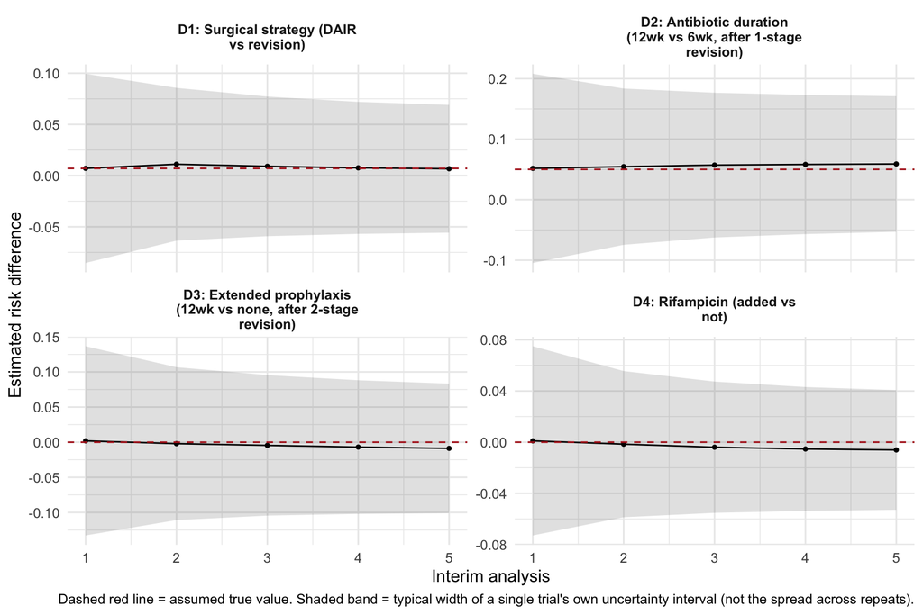

## d3 l-OR = 0.564 (approx 12pct)

**Assumed truth**

**D1: Surgical strategy (DAIR vs revision)** has a true effect of about 2.63 percentage points (risk-difference scale); **D3: Extended prophylaxis (12wk vs none, after 2-stage revision)** has a true effect of about 12.50 percentage points (risk-difference scale). Any remaining question is set to zero.

### Chance of reaching each decision

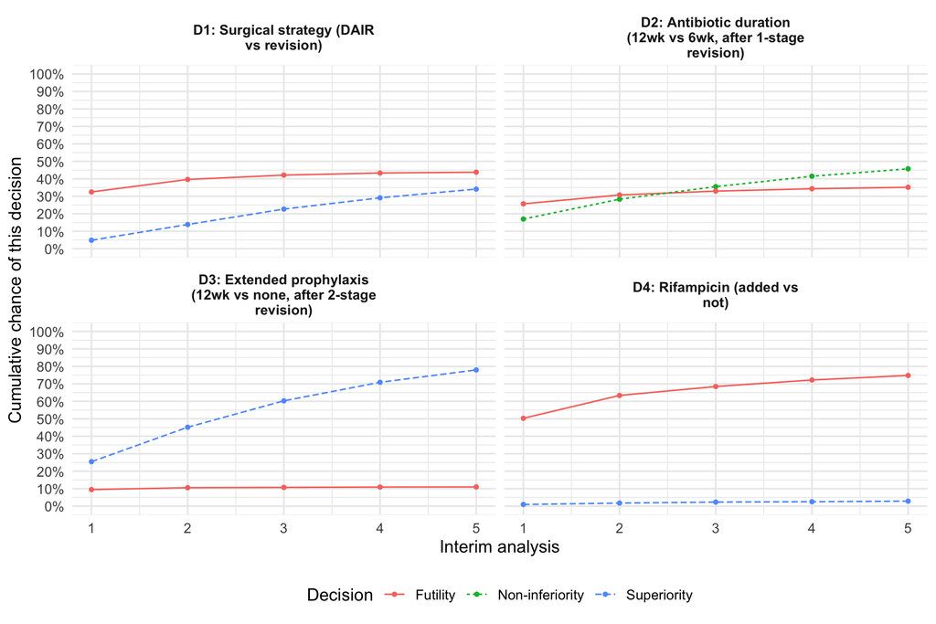

### Typical patient numbers

Patients enrolled by the time a decision is reached

| Domain | Rule | Chance of reaching a decision | Typical no. enrolled at decision | Typical no. informing this decision |
| --- | --- | --- | --- | --- |
| D1: Surgical strategy (DAIR vs revision) | Superiority | 34% | 1467 | 587 |
| D1: Surgical strategy (DAIR vs revision) | Futility | 44% | 701 | 280 |
| D2: Antibiotic duration (12wk vs 6wk, after 1-stage revision) | Non-inferiority | 46% | 1163 | 159 |
| D2: Antibiotic duration (12wk vs 6wk, after 1-stage revision) | Futility | 35% | 741 | 100 |
| D3: Extended prophylaxis (12wk vs none, after 2-stage revision) | Superiority | 78% | 1206 | 236 |
| D3: Extended prophylaxis (12wk vs none, after 2-stage revision) | Futility | 11% | 605 | 119 |
| D4: Rifampicin (added vs not) | Superiority | 3% | 1188 | 834 |
| D4: Rifampicin (added vs not) | Futility | 75% | 800 | 560 |

### Recovered vs. true effect

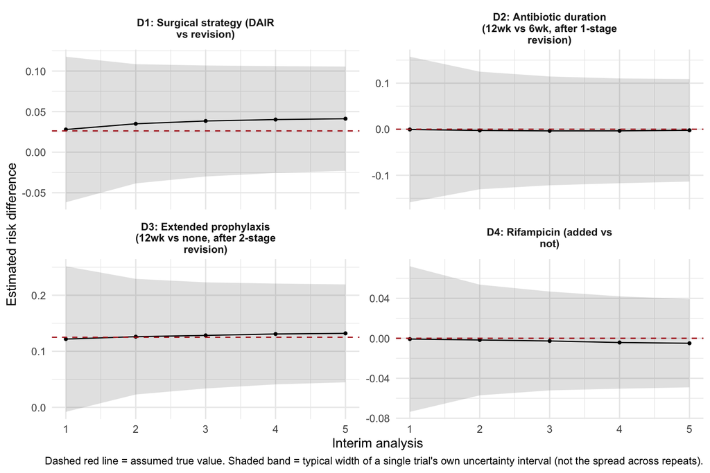

## d3 l-OR = 0.75

**Assumed truth**

**D1: Surgical strategy (DAIR vs revision)** has a true effect of about 3.37 percentage points (risk-difference scale); **D3: Extended prophylaxis (12wk vs none, after 2-stage revision)** has a true effect of about 16.05 percentage points (risk-difference scale). Any remaining question is set to zero.

### Chance of reaching each decision

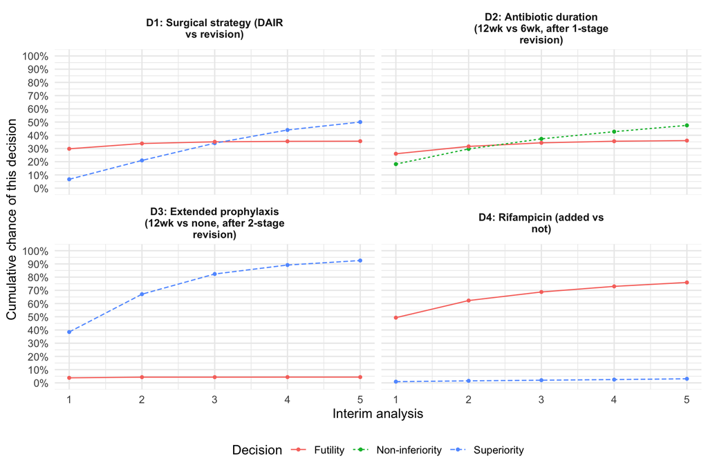

### Typical patient numbers

Patients enrolled by the time a decision is reached

| Domain | Rule | Chance of reaching a decision | Typical no. enrolled at decision | Typical no. informing this decision |
| --- | --- | --- | --- | --- |
| D1: Surgical strategy (DAIR vs revision) | Superiority | 50% | 1444 | 577 |
| D1: Surgical strategy (DAIR vs revision) | Futility | 36% | 614 | 245 |
| D2: Antibiotic duration (12wk vs 6wk, after 1-stage revision) | Non-inferiority | 47% | 1154 | 161 |
| D2: Antibiotic duration (12wk vs 6wk, after 1-stage revision) | Futility | 36% | 730 | 101 |
| D3: Extended prophylaxis (12wk vs none, after 2-stage revision) | Superiority | 93% | 1003 | 198 |
| D3: Extended prophylaxis (12wk vs none, after 2-stage revision) | Futility | 4% | 573 | 113 |
| D4: Rifampicin (added vs not) | Superiority | 3% | 1377 | 962 |
| D4: Rifampicin (added vs not) | Futility | 76% | 832 | 582 |

### Recovered vs. true effect

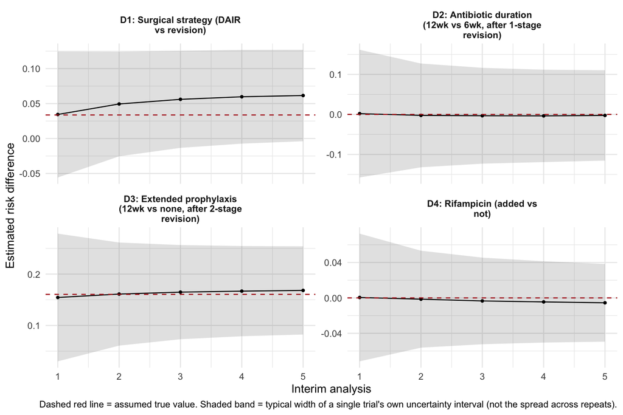

## Mix d2 l-OR = -0.1, d3 l-OR = 0.7, d4 l-OR = 0.3

**Assumed truth**

**D1: Surgical strategy (DAIR vs revision)** has a true effect of about 2.72 percentage points (risk-difference scale); **D2: Antibiotic duration (12wk vs 6wk, after 1-stage revision)** has a true effect of about -2.36 percentage points (risk-difference scale); **D3: Extended prophylaxis (12wk vs none, after 2-stage revision)** has a true effect of about 14.51 percentage points (risk-difference scale); **D4: Rifampicin (added vs not)** has a true effect of about 6.77 percentage points (risk-difference scale). Any remaining question is set to zero.

### Chance of reaching each decision

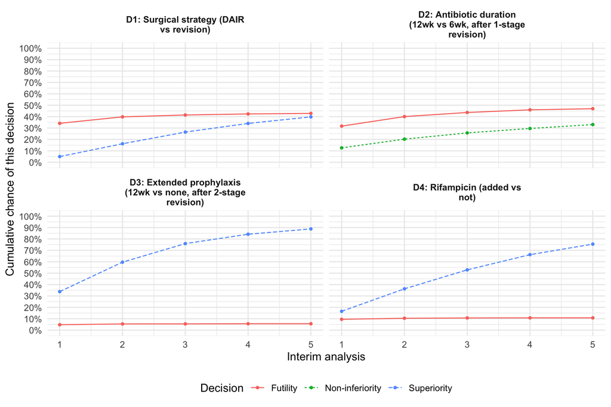

### Typical patient numbers

Patients enrolled by the time a decision is reached

| Domain | Rule | Chance of reaching a decision | Typical no. enrolled at decision | Typical no. informing this decision |
| --- | --- | --- | --- | --- |
| D1: Surgical strategy (DAIR vs revision) | Superiority | 40% | 1473 | 589 |
| D1: Surgical strategy (DAIR vs revision) | Futility | 43% | 659 | 264 |
| D2: Antibiotic duration (12wk vs 6wk, after 1-stage revision) | Non-inferiority | 33% | 1166 | 157 |
| D2: Antibiotic duration (12wk vs 6wk, after 1-stage revision) | Futility | 47% | 782 | 106 |
| D3: Extended prophylaxis (12wk vs none, after 2-stage revision) | Superiority | 89% | 1073 | 209 |
| D3: Extended prophylaxis (12wk vs none, after 2-stage revision) | Futility | 6% | 600 | 118 |
| D4: Rifampicin (added vs not) | Superiority | 75% | 1361 | 953 |
| D4: Rifampicin (added vs not) | Futility | 11% | 578 | 404 |

### Recovered vs. true effect

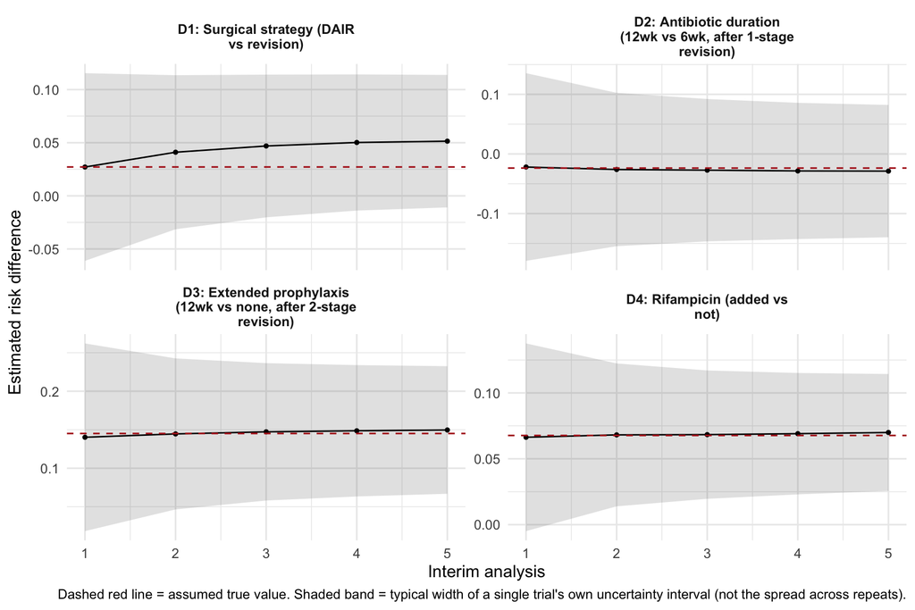

# Appendix

Further detail for readers wanting the numbers behind the plots above: bias, root-mean-square error (RMSE), and coverage of the 95% credible interval, on both the log-odds and risk-difference scales.

Regimen-level weights that are used to build each domain’s contrast are provided.

Coverage is the proportion of trials whose own credible interval contained the assumed true value.

## All domains log OR zero

### Standardised marginal log-odds ratio

| i_anlys | par | truth | mean_est | se_est | sd_est | bias | rmse | coverage |
| --- | --- | --- | --- | --- | --- | --- | --- | --- |
| 1 | d1 | 0.000 | 0.003 | 0.279 | 0.392 | 0.003 | 0.279 | 0.946 |
| 2 | d1 | 0.000 | −0.013 | 0.219 | 0.307 | −0.013 | 0.219 | 0.952 |
| 3 | d1 | 0.000 | −0.024 | 0.201 | 0.279 | −0.024 | 0.202 | 0.949 |
| 4 | d1 | 0.000 | −0.030 | 0.193 | 0.265 | −0.030 | 0.195 | 0.946 |
| 5 | d1 | 0.000 | −0.034 | 0.188 | 0.256 | −0.034 | 0.191 | 0.945 |
| 1 | d2 | 0.000 | 0.005 | 0.512 | 0.708 | 0.005 | 0.512 | 0.938 |
| 2 | d2 | 0.000 | −0.004 | 0.418 | 0.565 | −0.004 | 0.418 | 0.945 |
| 3 | d2 | 0.000 | −0.004 | 0.395 | 0.519 | −0.004 | 0.394 | 0.946 |
| 4 | d2 | 0.000 | −0.001 | 0.386 | 0.499 | −0.001 | 0.386 | 0.945 |
| 5 | d2 | 0.000 | −0.001 | 0.383 | 0.488 | −0.001 | 0.383 | 0.945 |
| 1 | d3 | 0.000 | 0.002 | 0.415 | 0.581 | 0.002 | 0.415 | 0.942 |
| 2 | d3 | 0.000 | −0.006 | 0.326 | 0.457 | −0.006 | 0.326 | 0.952 |
| 3 | d3 | 0.000 | −0.017 | 0.298 | 0.415 | −0.017 | 0.298 | 0.944 |
| 4 | d3 | 0.000 | −0.023 | 0.286 | 0.394 | −0.023 | 0.287 | 0.944 |
| 5 | d3 | 0.000 | −0.029 | 0.280 | 0.381 | −0.029 | 0.281 | 0.943 |
| 1 | d4 | 0.000 | 0.003 | 0.232 | 0.318 | 0.003 | 0.232 | 0.930 |
| 2 | d4 | 0.000 | −0.007 | 0.174 | 0.240 | −0.007 | 0.174 | 0.942 |
| 3 | d4 | 0.000 | −0.018 | 0.155 | 0.215 | −0.018 | 0.156 | 0.944 |
| 4 | d4 | 0.000 | −0.022 | 0.149 | 0.204 | −0.022 | 0.151 | 0.939 |
| 5 | d4 | 0.000 | −0.025 | 0.144 | 0.197 | −0.025 | 0.147 | 0.942 |

### Standardised marginal risk difference

| i_anlys | par | truth | mean_est | se_est | sd_est | bias | rmse | coverage |
| --- | --- | --- | --- | --- | --- | --- | --- | --- |
| 1 | d1 | 0.000 | 0.001 | 0.066 | 0.092 | 0.001 | 0.066 | 0.944 |
| 2 | d1 | 0.000 | 0.004 | 0.052 | 0.074 | 0.004 | 0.053 | 0.952 |
| 3 | d1 | 0.000 | 0.001 | 0.048 | 0.068 | 0.001 | 0.048 | 0.950 |
| 4 | d1 | 0.000 | 0.000 | 0.046 | 0.064 | 0.000 | 0.046 | 0.944 |
| 5 | d1 | 0.000 | −0.001 | 0.045 | 0.062 | −0.001 | 0.045 | 0.945 |
| 1 | d2 | 0.000 | 0.001 | 0.115 | 0.159 | 0.001 | 0.115 | 0.938 |
| 2 | d2 | 0.000 | −0.001 | 0.098 | 0.132 | −0.001 | 0.098 | 0.945 |
| 3 | d2 | 0.000 | −0.001 | 0.093 | 0.123 | −0.001 | 0.093 | 0.946 |
| 4 | d2 | 0.000 | 0.000 | 0.092 | 0.118 | 0.000 | 0.092 | 0.945 |
| 5 | d2 | 0.000 | 0.000 | 0.091 | 0.116 | 0.000 | 0.091 | 0.945 |
| 1 | d3 | 0.000 | 0.001 | 0.095 | 0.133 | 0.001 | 0.095 | 0.942 |
| 2 | d3 | 0.000 | −0.002 | 0.077 | 0.108 | −0.002 | 0.077 | 0.952 |
| 3 | d3 | 0.000 | −0.005 | 0.071 | 0.099 | −0.005 | 0.071 | 0.944 |
| 4 | d3 | 0.000 | −0.006 | 0.068 | 0.094 | −0.006 | 0.069 | 0.944 |
| 5 | d3 | 0.000 | −0.008 | 0.067 | 0.091 | −0.008 | 0.067 | 0.943 |
| 1 | d4 | 0.000 | 0.001 | 0.055 | 0.075 | 0.001 | 0.055 | 0.930 |
| 2 | d4 | 0.000 | −0.002 | 0.042 | 0.058 | −0.002 | 0.042 | 0.942 |
| 3 | d4 | 0.000 | −0.005 | 0.037 | 0.052 | −0.005 | 0.038 | 0.944 |
| 4 | d4 | 0.000 | −0.006 | 0.036 | 0.049 | −0.006 | 0.036 | 0.939 |
| 5 | d4 | 0.000 | −0.006 | 0.035 | 0.047 | −0.006 | 0.035 | 0.942 |

### Regimen weights by interim (mean, sd)

d1 regimen weights

| side | reg | 1 | 2 | 3 | 4 | 5 |
| --- | --- | --- | --- | --- | --- | --- |
| rev | l_r1_nad2_nad3 | 0.120 (0.032) | 0.120 (0.027) | 0.120 (0.026) | 0.120 (0.025) | 0.119 (0.024) |
| rev | l_r1_wk12_nad3 | 0.140 (0.023) | 0.150 (0.089) | 0.142 (0.102) | 0.133 (0.109) | 0.129 (0.113) |
| rev | l_r1_wk6_nad3 | 0.140 (0.023) | 0.129 (0.089) | 0.136 (0.102) | 0.145 (0.109) | 0.150 (0.113) |
| rev | l_r2_nad2_nad3 | 0.181 (0.038) | 0.181 (0.032) | 0.181 (0.030) | 0.181 (0.029) | 0.181 (0.028) |
| rev | l_r2_nad2_none | 0.210 (0.025) | 0.305 (0.118) | 0.319 (0.121) | 0.322 (0.123) | 0.323 (0.126) |
| rev | l_r2_nad2_wk12 | 0.210 (0.025) | 0.116 (0.114) | 0.102 (0.116) | 0.099 (0.119) | 0.098 (0.123) |

d2 regimen weights

| side | reg | 1 | 2 | 3 | 4 | 5 |
| --- | --- | --- | --- | --- | --- | --- |
| wk12 | cnrd1_r1_wk12_nad3 | 0.293 (0.044) | 0.325 (0.050) | 0.342 (0.058) | 0.353 (0.064) | 0.360 (0.068) |
| wk12 | enrd1_r1_wk12_nad3 | 0.219 (0.041) | 0.244 (0.042) | 0.257 (0.047) | 0.264 (0.049) | 0.269 (0.052) |
| wk12 | l_r1_wk12_nad3 | 0.390 (0.047) | 0.322 (0.083) | 0.287 (0.109) | 0.265 (0.124) | 0.250 (0.134) |
| wk12 | lnrd1_r1_wk12_nad3 | 0.098 (0.029) | 0.109 (0.026) | 0.114 (0.026) | 0.118 (0.027) | 0.120 (0.027) |
| wk6 | cnrd1_r1_wk6_nad3 | 0.293 (0.044) | 0.325 (0.050) | 0.342 (0.058) | 0.353 (0.064) | 0.360 (0.068) |
| wk6 | enrd1_r1_wk6_nad3 | 0.219 (0.041) | 0.244 (0.042) | 0.257 (0.047) | 0.264 (0.049) | 0.269 (0.052) |
| wk6 | l_r1_wk6_nad3 | 0.390 (0.047) | 0.322 (0.083) | 0.287 (0.109) | 0.265 (0.124) | 0.250 (0.134) |
| wk6 | lnrd1_r1_wk6_nad3 | 0.098 (0.029) | 0.109 (0.026) | 0.114 (0.026) | 0.118 (0.027) | 0.120 (0.027) |

d3 regimen weights

| side | reg | 1 | 2 | 3 | 4 | 5 |
| --- | --- | --- | --- | --- | --- | --- |
| none | cnrd1_r2_nad2_none | 0.337 (0.039) | 0.377 (0.054) | 0.399 (0.068) | 0.412 (0.076) | 0.421 (0.083) |
| none | enrd1_r2_nad2_none | 0.153 (0.029) | 0.170 (0.031) | 0.180 (0.034) | 0.185 (0.037) | 0.189 (0.039) |
| none | l_r2_nad2_none | 0.408 (0.041) | 0.339 (0.084) | 0.302 (0.113) | 0.280 (0.130) | 0.265 (0.142) |
| none | lnrd1_r2_nad2_none | 0.102 (0.026) | 0.114 (0.024) | 0.120 (0.026) | 0.124 (0.027) | 0.126 (0.028) |
| wk12 | cnrd1_r2_nad2_wk12 | 0.337 (0.039) | 0.377 (0.054) | 0.399 (0.068) | 0.412 (0.076) | 0.421 (0.083) |
| wk12 | enrd1_r2_nad2_wk12 | 0.153 (0.029) | 0.170 (0.031) | 0.180 (0.034) | 0.185 (0.037) | 0.189 (0.039) |
| wk12 | l_r2_nad2_wk12 | 0.408 (0.041) | 0.339 (0.084) | 0.302 (0.113) | 0.280 (0.130) | 0.265 (0.142) |
| wk12 | lnrd1_r2_nad2_wk12 | 0.102 (0.026) | 0.114 (0.024) | 0.120 (0.026) | 0.124 (0.027) | 0.126 (0.028) |

## d1 l-OR = 0.5

### Standardised marginal log-odds ratio

| i_anlys | par | truth | mean_est | se_est | sd_est | bias | rmse | coverage |
| --- | --- | --- | --- | --- | --- | --- | --- | --- |
| 1 | d1 | 0.500 | 0.494 | 0.278 | 0.400 | −0.006 | 0.278 | 0.958 |
| 2 | d1 | 0.500 | 0.505 | 0.222 | 0.310 | 0.005 | 0.222 | 0.950 |
| 3 | d1 | 0.500 | 0.515 | 0.204 | 0.280 | 0.015 | 0.205 | 0.948 |
| 4 | d1 | 0.500 | 0.522 | 0.194 | 0.265 | 0.022 | 0.195 | 0.954 |
| 5 | d1 | 0.500 | 0.525 | 0.190 | 0.258 | 0.025 | 0.191 | 0.955 |
| 1 | d2 | 0.000 | −0.002 | 0.528 | 0.727 | −0.002 | 0.528 | 0.936 |
| 2 | d2 | 0.000 | −0.004 | 0.409 | 0.549 | −0.004 | 0.409 | 0.947 |
| 3 | d2 | 0.000 | −0.008 | 0.395 | 0.507 | −0.008 | 0.395 | 0.945 |
| 4 | d2 | 0.000 | −0.005 | 0.391 | 0.489 | −0.005 | 0.391 | 0.940 |
| 5 | d2 | 0.000 | −0.003 | 0.390 | 0.481 | −0.003 | 0.390 | 0.937 |
| 1 | d3 | 0.000 | −0.005 | 0.418 | 0.587 | −0.005 | 0.418 | 0.940 |
| 2 | d3 | 0.000 | −0.030 | 0.310 | 0.436 | −0.030 | 0.311 | 0.943 |
| 3 | d3 | 0.000 | −0.043 | 0.288 | 0.395 | −0.043 | 0.292 | 0.942 |
| 4 | d3 | 0.000 | −0.054 | 0.275 | 0.372 | −0.054 | 0.281 | 0.944 |
| 5 | d3 | 0.000 | −0.062 | 0.270 | 0.358 | −0.062 | 0.277 | 0.937 |
| 1 | d4 | 0.000 | 0.000 | 0.223 | 0.311 | 0.000 | 0.223 | 0.946 |
| 2 | d4 | 0.000 | −0.007 | 0.167 | 0.236 | −0.007 | 0.167 | 0.944 |
| 3 | d4 | 0.000 | −0.016 | 0.152 | 0.212 | −0.016 | 0.153 | 0.947 |
| 4 | d4 | 0.000 | −0.022 | 0.144 | 0.198 | −0.022 | 0.145 | 0.949 |
| 5 | d4 | 0.000 | −0.026 | 0.140 | 0.189 | −0.026 | 0.142 | 0.951 |

### Standardised marginal risk difference

| i_anlys | par | truth | mean_est | se_est | sd_est | bias | rmse | coverage |
| --- | --- | --- | --- | --- | --- | --- | --- | --- |
| 1 | d1 | 0.112 | 0.108 | 0.060 | 0.087 | −0.004 | 0.060 | 0.957 |
| 2 | d1 | 0.112 | 0.117 | 0.049 | 0.069 | 0.005 | 0.050 | 0.953 |
| 3 | d1 | 0.112 | 0.120 | 0.046 | 0.063 | 0.008 | 0.046 | 0.949 |
| 4 | d1 | 0.112 | 0.121 | 0.044 | 0.060 | 0.009 | 0.044 | 0.954 |
| 5 | d1 | 0.112 | 0.122 | 0.043 | 0.059 | 0.009 | 0.044 | 0.957 |
| 1 | d2 | 0.000 | −0.001 | 0.113 | 0.155 | −0.001 | 0.113 | 0.936 |
| 2 | d2 | 0.000 | −0.001 | 0.092 | 0.124 | −0.001 | 0.092 | 0.947 |
| 3 | d2 | 0.000 | −0.002 | 0.090 | 0.116 | −0.002 | 0.090 | 0.945 |
| 4 | d2 | 0.000 | −0.001 | 0.089 | 0.112 | −0.001 | 0.089 | 0.940 |
| 5 | d2 | 0.000 | −0.001 | 0.089 | 0.110 | −0.001 | 0.089 | 0.937 |
| 1 | d3 | 0.000 | −0.001 | 0.091 | 0.128 | −0.001 | 0.091 | 0.940 |
| 2 | d3 | 0.000 | −0.008 | 0.070 | 0.099 | −0.008 | 0.071 | 0.943 |
| 3 | d3 | 0.000 | −0.011 | 0.066 | 0.090 | −0.011 | 0.067 | 0.942 |
| 4 | d3 | 0.000 | −0.014 | 0.063 | 0.084 | −0.014 | 0.064 | 0.944 |
| 5 | d3 | 0.000 | −0.015 | 0.061 | 0.081 | −0.015 | 0.063 | 0.937 |
| 1 | d4 | 0.000 | 0.000 | 0.052 | 0.072 | 0.000 | 0.052 | 0.946 |
| 2 | d4 | 0.000 | −0.002 | 0.039 | 0.055 | −0.002 | 0.039 | 0.944 |
| 3 | d4 | 0.000 | −0.004 | 0.036 | 0.050 | −0.004 | 0.036 | 0.947 |
| 4 | d4 | 0.000 | −0.006 | 0.034 | 0.046 | −0.006 | 0.034 | 0.949 |
| 5 | d4 | 0.000 | −0.006 | 0.033 | 0.044 | −0.006 | 0.033 | 0.951 |

### Regimen weights by interim (mean, sd)

d1 regimen weights

| side | reg | 1 | 2 | 3 | 4 | 5 |
| --- | --- | --- | --- | --- | --- | --- |
| rev | l_r1_nad2_nad3 | 0.120 (0.033) | 0.115 (0.023) | 0.111 (0.018) | 0.109 (0.016) | 0.107 (0.014) |
| rev | l_r1_wk12_nad3 | 0.139 (0.022) | 0.144 (0.089) | 0.130 (0.095) | 0.119 (0.099) | 0.112 (0.101) |
| rev | l_r1_wk6_nad3 | 0.139 (0.022) | 0.124 (0.088) | 0.130 (0.095) | 0.135 (0.099) | 0.138 (0.101) |
| rev | l_r2_nad2_nad3 | 0.181 (0.039) | 0.186 (0.027) | 0.189 (0.022) | 0.192 (0.019) | 0.194 (0.017) |
| rev | l_r2_nad2_none | 0.210 (0.025) | 0.315 (0.118) | 0.338 (0.121) | 0.343 (0.124) | 0.345 (0.127) |
| rev | l_r2_nad2_wk12 | 0.210 (0.025) | 0.116 (0.116) | 0.101 (0.120) | 0.102 (0.123) | 0.105 (0.127) |

d2 regimen weights

| side | reg | 1 | 2 | 3 | 4 | 5 |
| --- | --- | --- | --- | --- | --- | --- |
| wk12 | cnrd1_r1_wk12_nad3 | 0.294 (0.044) | 0.284 (0.037) | 0.276 (0.039) | 0.269 (0.040) | 0.263 (0.042) |
| wk12 | enrd1_r1_wk12_nad3 | 0.220 (0.041) | 0.212 (0.032) | 0.206 (0.031) | 0.201 (0.031) | 0.197 (0.033) |
| wk12 | l_r1_wk12_nad3 | 0.389 (0.048) | 0.409 (0.056) | 0.427 (0.067) | 0.442 (0.075) | 0.452 (0.081) |
| wk12 | lnrd1_r1_wk12_nad3 | 0.097 (0.030) | 0.095 (0.022) | 0.091 (0.019) | 0.089 (0.018) | 0.087 (0.017) |
| wk6 | cnrd1_r1_wk6_nad3 | 0.294 (0.044) | 0.284 (0.037) | 0.276 (0.039) | 0.269 (0.040) | 0.263 (0.042) |
| wk6 | enrd1_r1_wk6_nad3 | 0.220 (0.041) | 0.212 (0.032) | 0.206 (0.031) | 0.201 (0.031) | 0.197 (0.033) |
| wk6 | l_r1_wk6_nad3 | 0.389 (0.048) | 0.409 (0.056) | 0.427 (0.067) | 0.442 (0.075) | 0.452 (0.081) |
| wk6 | lnrd1_r1_wk6_nad3 | 0.097 (0.030) | 0.095 (0.022) | 0.091 (0.019) | 0.089 (0.018) | 0.087 (0.017) |

d3 regimen weights

| side | reg | 1 | 2 | 3 | 4 | 5 |
| --- | --- | --- | --- | --- | --- | --- |
| none | cnrd1_r2_nad2_none | 0.339 (0.039) | 0.318 (0.046) | 0.301 (0.051) | 0.287 (0.054) | 0.278 (0.057) |
| none | enrd1_r2_nad2_none | 0.152 (0.030) | 0.144 (0.026) | 0.136 (0.026) | 0.130 (0.026) | 0.125 (0.027) |
| none | l_r2_nad2_none | 0.408 (0.040) | 0.442 (0.070) | 0.473 (0.083) | 0.497 (0.091) | 0.514 (0.097) |
| none | lnrd1_r2_nad2_none | 0.102 (0.025) | 0.096 (0.020) | 0.090 (0.019) | 0.086 (0.019) | 0.083 (0.019) |
| wk12 | cnrd1_r2_nad2_wk12 | 0.339 (0.039) | 0.318 (0.046) | 0.301 (0.051) | 0.287 (0.054) | 0.278 (0.057) |
| wk12 | enrd1_r2_nad2_wk12 | 0.152 (0.030) | 0.144 (0.026) | 0.136 (0.026) | 0.130 (0.026) | 0.125 (0.027) |
| wk12 | l_r2_nad2_wk12 | 0.408 (0.040) | 0.442 (0.070) | 0.473 (0.083) | 0.497 (0.091) | 0.514 (0.097) |
| wk12 | lnrd1_r2_nad2_wk12 | 0.102 (0.025) | 0.096 (0.020) | 0.090 (0.019) | 0.086 (0.019) | 0.083 (0.019) |

## d1 l-OR = 0.3

### Standardised marginal log-odds ratio

| i_anlys | par | truth | mean_est | se_est | sd_est | bias | rmse | coverage |
| --- | --- | --- | --- | --- | --- | --- | --- | --- |
| 1 | d1 | 0.300 | 0.304 | 0.271 | 0.391 | 0.004 | 0.271 | 0.954 |
| 2 | d1 | 0.300 | 0.304 | 0.225 | 0.308 | 0.004 | 0.225 | 0.953 |
| 3 | d1 | 0.300 | 0.304 | 0.210 | 0.278 | 0.004 | 0.210 | 0.948 |
| 4 | d1 | 0.300 | 0.307 | 0.204 | 0.264 | 0.007 | 0.204 | 0.940 |
| 5 | d1 | 0.300 | 0.311 | 0.201 | 0.255 | 0.011 | 0.201 | 0.936 |
| 1 | d2 | 0.000 | 0.005 | 0.521 | 0.719 | 0.005 | 0.521 | 0.936 |
| 2 | d2 | 0.000 | −0.003 | 0.399 | 0.544 | −0.003 | 0.399 | 0.942 |
| 3 | d2 | 0.000 | −0.003 | 0.372 | 0.495 | −0.003 | 0.372 | 0.944 |
| 4 | d2 | 0.000 | 0.000 | 0.366 | 0.475 | 0.000 | 0.366 | 0.942 |
| 5 | d2 | 0.000 | 0.000 | 0.365 | 0.466 | 0.000 | 0.365 | 0.940 |
| 1 | d3 | 0.000 | −0.004 | 0.430 | 0.594 | −0.004 | 0.430 | 0.941 |
| 2 | d3 | 0.000 | −0.023 | 0.315 | 0.444 | −0.023 | 0.316 | 0.949 |
| 3 | d3 | 0.000 | −0.036 | 0.286 | 0.399 | −0.036 | 0.288 | 0.947 |
| 4 | d3 | 0.000 | −0.043 | 0.274 | 0.379 | −0.043 | 0.277 | 0.943 |
| 5 | d3 | 0.000 | −0.049 | 0.266 | 0.365 | −0.049 | 0.271 | 0.937 |
| 1 | d4 | 0.000 | 0.005 | 0.225 | 0.313 | 0.005 | 0.225 | 0.944 |
| 2 | d4 | 0.000 | −0.003 | 0.164 | 0.234 | −0.003 | 0.164 | 0.954 |
| 3 | d4 | 0.000 | −0.009 | 0.148 | 0.211 | −0.009 | 0.149 | 0.951 |
| 4 | d4 | 0.000 | −0.013 | 0.142 | 0.199 | −0.013 | 0.142 | 0.945 |
| 5 | d4 | 0.000 | −0.017 | 0.137 | 0.192 | −0.017 | 0.139 | 0.952 |

### Standardised marginal risk difference

| i_anlys | par | truth | mean_est | se_est | sd_est | bias | rmse | coverage |
| --- | --- | --- | --- | --- | --- | --- | --- | --- |
| 1 | d1 | 0.069 | 0.069 | 0.061 | 0.088 | −0.001 | 0.061 | 0.950 |
| 2 | d1 | 0.069 | 0.076 | 0.051 | 0.071 | 0.006 | 0.051 | 0.956 |
| 3 | d1 | 0.069 | 0.075 | 0.048 | 0.064 | 0.006 | 0.048 | 0.952 |
| 4 | d1 | 0.069 | 0.076 | 0.047 | 0.061 | 0.006 | 0.047 | 0.946 |
| 5 | d1 | 0.069 | 0.077 | 0.046 | 0.059 | 0.007 | 0.047 | 0.940 |
| 1 | d2 | 0.000 | 0.001 | 0.114 | 0.157 | 0.001 | 0.114 | 0.936 |
| 2 | d2 | 0.000 | −0.001 | 0.093 | 0.126 | −0.001 | 0.093 | 0.942 |
| 3 | d2 | 0.000 | −0.001 | 0.088 | 0.116 | −0.001 | 0.088 | 0.944 |
| 4 | d2 | 0.000 | 0.000 | 0.086 | 0.112 | 0.000 | 0.086 | 0.942 |
| 5 | d2 | 0.000 | 0.000 | 0.086 | 0.110 | 0.000 | 0.086 | 0.940 |
| 1 | d3 | 0.000 | −0.001 | 0.096 | 0.132 | −0.001 | 0.096 | 0.941 |
| 2 | d3 | 0.000 | −0.006 | 0.073 | 0.103 | −0.006 | 0.073 | 0.949 |
| 3 | d3 | 0.000 | −0.010 | 0.067 | 0.093 | −0.010 | 0.068 | 0.947 |
| 4 | d3 | 0.000 | −0.011 | 0.064 | 0.088 | −0.011 | 0.065 | 0.943 |
| 5 | d3 | 0.000 | −0.013 | 0.062 | 0.085 | −0.013 | 0.064 | 0.937 |
| 1 | d4 | 0.000 | 0.001 | 0.053 | 0.073 | 0.001 | 0.053 | 0.944 |
| 2 | d4 | 0.000 | −0.001 | 0.039 | 0.055 | −0.001 | 0.039 | 0.954 |
| 3 | d4 | 0.000 | −0.003 | 0.035 | 0.050 | −0.003 | 0.035 | 0.951 |
| 4 | d4 | 0.000 | −0.004 | 0.034 | 0.047 | −0.004 | 0.034 | 0.945 |
| 5 | d4 | 0.000 | −0.004 | 0.033 | 0.046 | −0.004 | 0.033 | 0.952 |

### Regimen weights by interim (mean, sd)

d1 regimen weights

| side | reg | 1 | 2 | 3 | 4 | 5 |
| --- | --- | --- | --- | --- | --- | --- |
| rev | l_r1_nad2_nad3 | 0.120 (0.032) | 0.118 (0.024) | 0.116 (0.021) | 0.115 (0.019) | 0.113 (0.018) |
| rev | l_r1_wk12_nad3 | 0.139 (0.023) | 0.146 (0.090) | 0.135 (0.102) | 0.124 (0.106) | 0.116 (0.109) |
| rev | l_r1_wk6_nad3 | 0.139 (0.023) | 0.129 (0.090) | 0.136 (0.103) | 0.143 (0.107) | 0.148 (0.110) |
| rev | l_r2_nad2_nad3 | 0.181 (0.038) | 0.182 (0.029) | 0.184 (0.025) | 0.185 (0.022) | 0.186 (0.021) |
| rev | l_r2_nad2_none | 0.210 (0.025) | 0.312 (0.118) | 0.334 (0.121) | 0.343 (0.122) | 0.343 (0.125) |
| rev | l_r2_nad2_wk12 | 0.210 (0.025) | 0.114 (0.116) | 0.096 (0.120) | 0.089 (0.121) | 0.093 (0.125) |

d2 regimen weights

| side | reg | 1 | 2 | 3 | 4 | 5 |
| --- | --- | --- | --- | --- | --- | --- |
| wk12 | cnrd1_r1_wk12_nad3 | 0.293 (0.046) | 0.297 (0.043) | 0.296 (0.048) | 0.294 (0.053) | 0.292 (0.057) |
| wk12 | enrd1_r1_wk12_nad3 | 0.220 (0.041) | 0.223 (0.037) | 0.222 (0.039) | 0.220 (0.041) | 0.219 (0.044) |
| wk12 | l_r1_wk12_nad3 | 0.389 (0.048) | 0.381 (0.067) | 0.384 (0.086) | 0.388 (0.102) | 0.392 (0.111) |
| wk12 | lnrd1_r1_wk12_nad3 | 0.098 (0.029) | 0.099 (0.023) | 0.099 (0.021) | 0.098 (0.022) | 0.097 (0.022) |
| wk6 | cnrd1_r1_wk6_nad3 | 0.293 (0.046) | 0.297 (0.043) | 0.296 (0.048) | 0.294 (0.053) | 0.292 (0.057) |
| wk6 | enrd1_r1_wk6_nad3 | 0.220 (0.041) | 0.223 (0.037) | 0.222 (0.039) | 0.220 (0.041) | 0.219 (0.044) |
| wk6 | l_r1_wk6_nad3 | 0.389 (0.048) | 0.381 (0.067) | 0.384 (0.086) | 0.388 (0.102) | 0.392 (0.111) |
| wk6 | lnrd1_r1_wk6_nad3 | 0.098 (0.029) | 0.099 (0.023) | 0.099 (0.021) | 0.098 (0.022) | 0.097 (0.022) |

d3 regimen weights

| side | reg | 1 | 2 | 3 | 4 | 5 |
| --- | --- | --- | --- | --- | --- | --- |
| none | cnrd1_r2_nad2_none | 0.338 (0.039) | 0.340 (0.048) | 0.335 (0.061) | 0.330 (0.070) | 0.326 (0.076) |
| none | enrd1_r2_nad2_none | 0.152 (0.030) | 0.153 (0.027) | 0.150 (0.030) | 0.148 (0.033) | 0.146 (0.035) |
| none | l_r2_nad2_none | 0.408 (0.040) | 0.405 (0.075) | 0.415 (0.100) | 0.423 (0.119) | 0.430 (0.131) |
| none | lnrd1_r2_nad2_none | 0.102 (0.025) | 0.102 (0.021) | 0.100 (0.022) | 0.099 (0.023) | 0.098 (0.024) |
| wk12 | cnrd1_r2_nad2_wk12 | 0.338 (0.039) | 0.340 (0.048) | 0.335 (0.061) | 0.330 (0.070) | 0.326 (0.076) |
| wk12 | enrd1_r2_nad2_wk12 | 0.152 (0.030) | 0.153 (0.027) | 0.150 (0.030) | 0.148 (0.033) | 0.146 (0.035) |
| wk12 | l_r2_nad2_wk12 | 0.408 (0.040) | 0.405 (0.075) | 0.415 (0.100) | 0.423 (0.119) | 0.430 (0.131) |
| wk12 | lnrd1_r2_nad2_wk12 | 0.102 (0.025) | 0.102 (0.021) | 0.100 (0.022) | 0.099 (0.023) | 0.098 (0.024) |

## d4 l-OR = 0.5

### Standardised marginal log-odds ratio

| i_anlys | par | truth | mean_est | se_est | sd_est | bias | rmse | coverage |
| --- | --- | --- | --- | --- | --- | --- | --- | --- |
| 1 | d1 | 0.000 | 0.006 | 0.279 | 0.395 | 0.006 | 0.279 | 0.948 |
| 2 | d1 | 0.000 | −0.016 | 0.220 | 0.309 | −0.016 | 0.220 | 0.946 |
| 3 | d1 | 0.000 | −0.027 | 0.203 | 0.281 | −0.027 | 0.204 | 0.942 |
| 4 | d1 | 0.000 | −0.034 | 0.195 | 0.266 | −0.034 | 0.198 | 0.946 |
| 5 | d1 | 0.000 | −0.039 | 0.191 | 0.258 | −0.039 | 0.195 | 0.942 |
| 1 | d2 | 0.000 | 0.004 | 0.518 | 0.719 | 0.004 | 0.518 | 0.942 |
| 2 | d2 | 0.000 | −0.004 | 0.415 | 0.567 | −0.004 | 0.415 | 0.950 |
| 3 | d2 | 0.000 | −0.008 | 0.394 | 0.522 | −0.008 | 0.394 | 0.957 |
| 4 | d2 | 0.000 | −0.006 | 0.389 | 0.502 | −0.006 | 0.389 | 0.954 |
| 5 | d2 | 0.000 | −0.005 | 0.387 | 0.491 | −0.005 | 0.387 | 0.949 |
| 1 | d3 | 0.000 | −0.003 | 0.431 | 0.596 | −0.003 | 0.431 | 0.936 |
| 2 | d3 | 0.000 | −0.002 | 0.330 | 0.464 | −0.002 | 0.330 | 0.942 |
| 3 | d3 | 0.000 | −0.016 | 0.305 | 0.422 | −0.016 | 0.305 | 0.944 |
| 4 | d3 | 0.000 | −0.023 | 0.294 | 0.401 | −0.023 | 0.295 | 0.944 |
| 5 | d3 | 0.000 | −0.030 | 0.286 | 0.386 | −0.030 | 0.287 | 0.937 |
| 1 | d4 | 0.500 | 0.503 | 0.228 | 0.321 | 0.003 | 0.228 | 0.941 |
| 2 | d4 | 0.500 | 0.507 | 0.174 | 0.243 | 0.007 | 0.174 | 0.950 |
| 3 | d4 | 0.500 | 0.513 | 0.155 | 0.218 | 0.013 | 0.156 | 0.952 |
| 4 | d4 | 0.500 | 0.513 | 0.148 | 0.208 | 0.013 | 0.148 | 0.956 |
| 5 | d4 | 0.500 | 0.514 | 0.145 | 0.204 | 0.014 | 0.145 | 0.960 |

### Standardised marginal risk difference

| i_anlys | par | truth | mean_est | se_est | sd_est | bias | rmse | coverage |
| --- | --- | --- | --- | --- | --- | --- | --- | --- |
| 1 | d1 | 0.000 | 0.001 | 0.063 | 0.089 | 0.001 | 0.063 | 0.948 |
| 2 | d1 | 0.000 | 0.003 | 0.051 | 0.072 | 0.003 | 0.051 | 0.949 |
| 3 | d1 | 0.000 | 0.001 | 0.046 | 0.065 | 0.001 | 0.046 | 0.944 |
| 4 | d1 | 0.000 | −0.001 | 0.045 | 0.061 | −0.001 | 0.045 | 0.943 |
| 5 | d1 | 0.000 | −0.003 | 0.044 | 0.059 | −0.003 | 0.044 | 0.937 |
| 1 | d2 | 0.000 | 0.001 | 0.111 | 0.155 | 0.001 | 0.111 | 0.942 |
| 2 | d2 | 0.000 | −0.001 | 0.094 | 0.128 | −0.001 | 0.094 | 0.950 |
| 3 | d2 | 0.000 | −0.002 | 0.090 | 0.118 | −0.002 | 0.090 | 0.957 |
| 4 | d2 | 0.000 | −0.002 | 0.089 | 0.114 | −0.002 | 0.089 | 0.954 |
| 5 | d2 | 0.000 | −0.001 | 0.088 | 0.112 | −0.001 | 0.088 | 0.949 |
| 1 | d3 | 0.000 | −0.001 | 0.094 | 0.131 | −0.001 | 0.094 | 0.936 |
| 2 | d3 | 0.000 | −0.002 | 0.075 | 0.105 | −0.002 | 0.075 | 0.942 |
| 3 | d3 | 0.000 | −0.005 | 0.069 | 0.095 | −0.005 | 0.069 | 0.944 |
| 4 | d3 | 0.000 | −0.007 | 0.067 | 0.090 | −0.007 | 0.067 | 0.944 |
| 5 | d3 | 0.000 | −0.008 | 0.065 | 0.087 | −0.008 | 0.065 | 0.937 |
| 1 | d4 | 0.112 | 0.111 | 0.050 | 0.070 | −0.001 | 0.050 | 0.943 |
| 2 | d4 | 0.112 | 0.113 | 0.039 | 0.055 | 0.001 | 0.039 | 0.951 |
| 3 | d4 | 0.112 | 0.115 | 0.035 | 0.050 | 0.003 | 0.035 | 0.954 |
| 4 | d4 | 0.112 | 0.115 | 0.034 | 0.048 | 0.003 | 0.034 | 0.958 |
| 5 | d4 | 0.112 | 0.115 | 0.033 | 0.047 | 0.003 | 0.033 | 0.963 |

### Regimen weights by interim (mean, sd)

d1 regimen weights

| side | reg | 1 | 2 | 3 | 4 | 5 |
| --- | --- | --- | --- | --- | --- | --- |
| rev | l_r1_nad2_nad3 | 0.120 (0.033) | 0.120 (0.028) | 0.120 (0.026) | 0.119 (0.025) | 0.119 (0.025) |
| rev | l_r1_wk12_nad3 | 0.140 (0.023) | 0.149 (0.091) | 0.137 (0.102) | 0.136 (0.105) | 0.132 (0.108) |
| rev | l_r1_wk6_nad3 | 0.140 (0.023) | 0.130 (0.090) | 0.141 (0.101) | 0.142 (0.104) | 0.147 (0.108) |
| rev | l_r2_nad2_nad3 | 0.179 (0.039) | 0.180 (0.033) | 0.180 (0.030) | 0.180 (0.029) | 0.180 (0.028) |
| rev | l_r2_nad2_none | 0.211 (0.025) | 0.308 (0.119) | 0.316 (0.123) | 0.316 (0.125) | 0.313 (0.126) |
| rev | l_r2_nad2_wk12 | 0.211 (0.025) | 0.114 (0.116) | 0.106 (0.120) | 0.106 (0.123) | 0.109 (0.125) |

d2 regimen weights

| side | reg | 1 | 2 | 3 | 4 | 5 |
| --- | --- | --- | --- | --- | --- | --- |
| wk12 | cnrd1_r1_wk12_nad3 | 0.293 (0.045) | 0.325 (0.051) | 0.339 (0.059) | 0.347 (0.065) | 0.353 (0.070) |
| wk12 | enrd1_r1_wk12_nad3 | 0.218 (0.041) | 0.243 (0.042) | 0.254 (0.046) | 0.260 (0.050) | 0.264 (0.052) |
| wk12 | l_r1_wk12_nad3 | 0.392 (0.049) | 0.324 (0.083) | 0.294 (0.109) | 0.279 (0.125) | 0.266 (0.135) |
| wk12 | lnrd1_r1_wk12_nad3 | 0.097 (0.030) | 0.108 (0.026) | 0.113 (0.026) | 0.115 (0.025) | 0.117 (0.026) |
| wk6 | cnrd1_r1_wk6_nad3 | 0.293 (0.045) | 0.325 (0.051) | 0.339 (0.059) | 0.347 (0.065) | 0.353 (0.070) |
| wk6 | enrd1_r1_wk6_nad3 | 0.218 (0.041) | 0.243 (0.042) | 0.254 (0.046) | 0.260 (0.050) | 0.264 (0.052) |
| wk6 | l_r1_wk6_nad3 | 0.392 (0.049) | 0.324 (0.083) | 0.294 (0.109) | 0.279 (0.125) | 0.266 (0.135) |
| wk6 | lnrd1_r1_wk6_nad3 | 0.097 (0.030) | 0.108 (0.026) | 0.113 (0.026) | 0.115 (0.025) | 0.117 (0.026) |

d3 regimen weights

| side | reg | 1 | 2 | 3 | 4 | 5 |
| --- | --- | --- | --- | --- | --- | --- |
| none | cnrd1_r2_nad2_none | 0.340 (0.038) | 0.377 (0.054) | 0.394 (0.069) | 0.404 (0.078) | 0.412 (0.084) |
| none | enrd1_r2_nad2_none | 0.151 (0.030) | 0.170 (0.030) | 0.178 (0.034) | 0.181 (0.037) | 0.185 (0.039) |
| none | l_r2_nad2_none | 0.407 (0.040) | 0.340 (0.084) | 0.309 (0.113) | 0.293 (0.130) | 0.280 (0.142) |
| none | lnrd1_r2_nad2_none | 0.102 (0.024) | 0.113 (0.024) | 0.119 (0.026) | 0.121 (0.027) | 0.123 (0.027) |
| wk12 | cnrd1_r2_nad2_wk12 | 0.340 (0.038) | 0.377 (0.054) | 0.394 (0.069) | 0.404 (0.078) | 0.412 (0.084) |
| wk12 | enrd1_r2_nad2_wk12 | 0.151 (0.030) | 0.170 (0.030) | 0.178 (0.034) | 0.181 (0.037) | 0.185 (0.039) |
| wk12 | l_r2_nad2_wk12 | 0.407 (0.040) | 0.340 (0.084) | 0.309 (0.113) | 0.293 (0.130) | 0.280 (0.142) |
| wk12 | lnrd1_r2_nad2_wk12 | 0.102 (0.024) | 0.113 (0.024) | 0.119 (0.026) | 0.121 (0.027) | 0.123 (0.027) |

## d4 l-OR = 0.3

### Standardised marginal log-odds ratio

| i_anlys | par | truth | mean_est | se_est | sd_est | bias | rmse | coverage |
| --- | --- | --- | --- | --- | --- | --- | --- | --- |
| 1 | d1 | 0.000 | 0.002 | 0.276 | 0.392 | 0.002 | 0.276 | 0.951 |
| 2 | d1 | 0.000 | −0.010 | 0.216 | 0.306 | −0.010 | 0.216 | 0.942 |
| 3 | d1 | 0.000 | −0.019 | 0.197 | 0.278 | −0.019 | 0.198 | 0.943 |
| 4 | d1 | 0.000 | −0.026 | 0.189 | 0.263 | −0.026 | 0.191 | 0.942 |
| 5 | d1 | 0.000 | −0.030 | 0.185 | 0.255 | −0.030 | 0.187 | 0.939 |
| 1 | d2 | 0.000 | 0.022 | 0.502 | 0.705 | 0.022 | 0.503 | 0.941 |
| 2 | d2 | 0.000 | 0.011 | 0.407 | 0.559 | 0.011 | 0.407 | 0.948 |
| 3 | d2 | 0.000 | 0.008 | 0.379 | 0.510 | 0.008 | 0.379 | 0.956 |
| 4 | d2 | 0.000 | 0.005 | 0.372 | 0.489 | 0.005 | 0.372 | 0.952 |
| 5 | d2 | 0.000 | 0.006 | 0.368 | 0.475 | 0.006 | 0.368 | 0.952 |
| 1 | d3 | 0.000 | 0.005 | 0.433 | 0.597 | 0.005 | 0.433 | 0.940 |
| 2 | d3 | 0.000 | −0.008 | 0.338 | 0.469 | −0.008 | 0.338 | 0.942 |
| 3 | d3 | 0.000 | −0.019 | 0.303 | 0.421 | −0.019 | 0.303 | 0.942 |
| 4 | d3 | 0.000 | −0.026 | 0.287 | 0.398 | −0.026 | 0.288 | 0.942 |
| 5 | d3 | 0.000 | −0.030 | 0.280 | 0.384 | −0.030 | 0.281 | 0.942 |
| 1 | d4 | 0.300 | 0.307 | 0.230 | 0.319 | 0.007 | 0.230 | 0.940 |
| 2 | d4 | 0.300 | 0.306 | 0.179 | 0.242 | 0.006 | 0.179 | 0.947 |
| 3 | d4 | 0.300 | 0.310 | 0.165 | 0.217 | 0.010 | 0.165 | 0.943 |
| 4 | d4 | 0.300 | 0.314 | 0.158 | 0.204 | 0.014 | 0.159 | 0.946 |
| 5 | d4 | 0.300 | 0.318 | 0.154 | 0.197 | 0.018 | 0.155 | 0.946 |

### Standardised marginal risk difference

| i_anlys | par | truth | mean_est | se_est | sd_est | bias | rmse | coverage |
| --- | --- | --- | --- | --- | --- | --- | --- | --- |
| 1 | d1 | 0.000 | 0.000 | 0.063 | 0.090 | 0.000 | 0.063 | 0.951 |
| 2 | d1 | 0.000 | 0.005 | 0.050 | 0.072 | 0.005 | 0.050 | 0.941 |
| 3 | d1 | 0.000 | 0.003 | 0.046 | 0.065 | 0.003 | 0.046 | 0.946 |
| 4 | d1 | 0.000 | 0.001 | 0.044 | 0.062 | 0.001 | 0.044 | 0.945 |
| 5 | d1 | 0.000 | 0.001 | 0.043 | 0.060 | 0.001 | 0.043 | 0.942 |
| 1 | d2 | 0.000 | 0.005 | 0.110 | 0.155 | 0.005 | 0.110 | 0.941 |
| 2 | d2 | 0.000 | 0.002 | 0.094 | 0.129 | 0.002 | 0.094 | 0.948 |
| 3 | d2 | 0.000 | 0.002 | 0.089 | 0.119 | 0.002 | 0.089 | 0.956 |
| 4 | d2 | 0.000 | 0.001 | 0.087 | 0.114 | 0.001 | 0.087 | 0.952 |
| 5 | d2 | 0.000 | 0.001 | 0.086 | 0.111 | 0.001 | 0.086 | 0.952 |
| 1 | d3 | 0.000 | 0.001 | 0.097 | 0.134 | 0.001 | 0.097 | 0.940 |
| 2 | d3 | 0.000 | −0.003 | 0.078 | 0.108 | −0.003 | 0.078 | 0.942 |
| 3 | d3 | 0.000 | −0.006 | 0.071 | 0.098 | −0.006 | 0.071 | 0.942 |
| 4 | d3 | 0.000 | −0.007 | 0.067 | 0.093 | −0.007 | 0.068 | 0.942 |
| 5 | d3 | 0.000 | −0.008 | 0.066 | 0.090 | −0.008 | 0.066 | 0.942 |
| 1 | d4 | 0.069 | 0.070 | 0.052 | 0.072 | 0.001 | 0.052 | 0.939 |
| 2 | d4 | 0.069 | 0.071 | 0.041 | 0.056 | 0.001 | 0.041 | 0.948 |
| 3 | d4 | 0.069 | 0.072 | 0.038 | 0.050 | 0.002 | 0.038 | 0.945 |
| 4 | d4 | 0.069 | 0.073 | 0.037 | 0.048 | 0.003 | 0.037 | 0.948 |
| 5 | d4 | 0.069 | 0.074 | 0.036 | 0.046 | 0.004 | 0.036 | 0.945 |

### Regimen weights by interim (mean, sd)

d1 regimen weights

| side | reg | 1 | 2 | 3 | 4 | 5 |
| --- | --- | --- | --- | --- | --- | --- |
| rev | l_r1_nad2_nad3 | 0.120 (0.033) | 0.119 (0.028) | 0.119 (0.026) | 0.119 (0.025) | 0.119 (0.025) |
| rev | l_r1_wk12_nad3 | 0.140 (0.023) | 0.146 (0.091) | 0.137 (0.104) | 0.129 (0.110) | 0.122 (0.112) |
| rev | l_r1_wk6_nad3 | 0.140 (0.023) | 0.134 (0.091) | 0.142 (0.106) | 0.151 (0.111) | 0.158 (0.113) |
| rev | l_r2_nad2_nad3 | 0.182 (0.038) | 0.182 (0.034) | 0.182 (0.032) | 0.182 (0.031) | 0.181 (0.030) |
| rev | l_r2_nad2_none | 0.209 (0.025) | 0.305 (0.120) | 0.321 (0.124) | 0.323 (0.127) | 0.322 (0.128) |
| rev | l_r2_nad2_wk12 | 0.209 (0.025) | 0.114 (0.115) | 0.098 (0.120) | 0.097 (0.123) | 0.098 (0.124) |

d2 regimen weights

| side | reg | 1 | 2 | 3 | 4 | 5 |
| --- | --- | --- | --- | --- | --- | --- |
| wk12 | cnrd1_r1_wk12_nad3 | 0.293 (0.045) | 0.327 (0.049) | 0.345 (0.058) | 0.353 (0.064) | 0.360 (0.067) |
| wk12 | enrd1_r1_wk12_nad3 | 0.219 (0.042) | 0.244 (0.042) | 0.257 (0.046) | 0.265 (0.050) | 0.269 (0.053) |
| wk12 | l_r1_wk12_nad3 | 0.391 (0.047) | 0.320 (0.082) | 0.284 (0.108) | 0.264 (0.124) | 0.251 (0.134) |
| wk12 | lnrd1_r1_wk12_nad3 | 0.097 (0.030) | 0.109 (0.026) | 0.114 (0.026) | 0.117 (0.026) | 0.120 (0.027) |
| wk6 | cnrd1_r1_wk6_nad3 | 0.293 (0.045) | 0.327 (0.049) | 0.345 (0.058) | 0.353 (0.064) | 0.360 (0.067) |
| wk6 | enrd1_r1_wk6_nad3 | 0.219 (0.042) | 0.244 (0.042) | 0.257 (0.046) | 0.265 (0.050) | 0.269 (0.053) |
| wk6 | l_r1_wk6_nad3 | 0.391 (0.047) | 0.320 (0.082) | 0.284 (0.108) | 0.264 (0.124) | 0.251 (0.134) |
| wk6 | lnrd1_r1_wk6_nad3 | 0.097 (0.030) | 0.109 (0.026) | 0.114 (0.026) | 0.117 (0.026) | 0.120 (0.027) |

d3 regimen weights

| side | reg | 1 | 2 | 3 | 4 | 5 |
| --- | --- | --- | --- | --- | --- | --- |
| none | cnrd1_r2_nad2_none | 0.340 (0.040) | 0.379 (0.056) | 0.401 (0.069) | 0.412 (0.078) | 0.419 (0.084) |
| none | enrd1_r2_nad2_none | 0.152 (0.030) | 0.171 (0.032) | 0.180 (0.036) | 0.186 (0.039) | 0.189 (0.041) |
| none | l_r2_nad2_none | 0.406 (0.042) | 0.336 (0.086) | 0.300 (0.115) | 0.279 (0.133) | 0.266 (0.143) |
| none | lnrd1_r2_nad2_none | 0.101 (0.025) | 0.114 (0.024) | 0.119 (0.025) | 0.123 (0.026) | 0.125 (0.027) |
| wk12 | cnrd1_r2_nad2_wk12 | 0.340 (0.040) | 0.379 (0.056) | 0.401 (0.069) | 0.412 (0.078) | 0.419 (0.084) |
| wk12 | enrd1_r2_nad2_wk12 | 0.152 (0.030) | 0.171 (0.032) | 0.180 (0.036) | 0.186 (0.039) | 0.189 (0.041) |
| wk12 | l_r2_nad2_wk12 | 0.406 (0.042) | 0.336 (0.086) | 0.300 (0.115) | 0.279 (0.133) | 0.266 (0.143) |
| wk12 | lnrd1_r2_nad2_wk12 | 0.101 (0.025) | 0.114 (0.024) | 0.119 (0.025) | 0.123 (0.026) | 0.125 (0.027) |

## d2 l-OR = -0.305 (around -7.5pct)

### Standardised marginal log-odds ratio

| i_anlys | par | truth | mean_est | se_est | sd_est | bias | rmse | coverage |
| --- | --- | --- | --- | --- | --- | --- | --- | --- |
| 1 | d1 | −0.043 | −0.035 | 0.272 | 0.387 | 0.007 | 0.272 | 0.951 |
| 2 | d1 | −0.043 | −0.051 | 0.221 | 0.309 | −0.009 | 0.221 | 0.942 |
| 3 | d1 | −0.043 | −0.064 | 0.204 | 0.282 | −0.021 | 0.205 | 0.936 |
| 4 | d1 | −0.043 | −0.071 | 0.196 | 0.267 | −0.028 | 0.198 | 0.936 |
| 5 | d1 | −0.043 | −0.075 | 0.192 | 0.259 | −0.032 | 0.194 | 0.930 |
| 1 | d2 | −0.305 | −0.319 | 0.496 | 0.692 | −0.014 | 0.496 | 0.940 |
| 2 | d2 | −0.305 | −0.335 | 0.388 | 0.545 | −0.030 | 0.389 | 0.955 |
| 3 | d2 | −0.305 | −0.342 | 0.366 | 0.504 | −0.037 | 0.368 | 0.956 |
| 4 | d2 | −0.305 | −0.351 | 0.355 | 0.484 | −0.046 | 0.358 | 0.953 |
| 5 | d2 | −0.305 | −0.354 | 0.350 | 0.472 | −0.049 | 0.353 | 0.952 |
| 1 | d3 | 0.000 | −0.002 | 0.417 | 0.581 | −0.002 | 0.417 | 0.940 |
| 2 | d3 | 0.000 | −0.015 | 0.328 | 0.459 | −0.015 | 0.328 | 0.948 |
| 3 | d3 | 0.000 | −0.028 | 0.301 | 0.417 | −0.028 | 0.302 | 0.947 |
| 4 | d3 | 0.000 | −0.035 | 0.291 | 0.398 | −0.035 | 0.293 | 0.943 |
| 5 | d3 | 0.000 | −0.039 | 0.285 | 0.386 | −0.039 | 0.288 | 0.939 |
| 1 | d4 | 0.000 | −0.001 | 0.221 | 0.309 | −0.001 | 0.221 | 0.941 |
| 2 | d4 | 0.000 | −0.012 | 0.168 | 0.236 | −0.012 | 0.169 | 0.949 |
| 3 | d4 | 0.000 | −0.021 | 0.154 | 0.213 | −0.021 | 0.155 | 0.949 |
| 4 | d4 | 0.000 | −0.027 | 0.147 | 0.202 | −0.027 | 0.149 | 0.949 |
| 5 | d4 | 0.000 | −0.032 | 0.142 | 0.194 | −0.032 | 0.145 | 0.950 |

### Standardised marginal risk difference

| i_anlys | par | truth | mean_est | se_est | sd_est | bias | rmse | coverage |
| --- | --- | --- | --- | --- | --- | --- | --- | --- |
| 1 | d1 | −0.010 | −0.009 | 0.064 | 0.092 | 0.002 | 0.064 | 0.949 |
| 2 | d1 | −0.010 | −0.003 | 0.053 | 0.075 | 0.008 | 0.054 | 0.942 |
| 3 | d1 | −0.010 | −0.006 | 0.049 | 0.068 | 0.005 | 0.049 | 0.939 |
| 4 | d1 | −0.010 | −0.007 | 0.047 | 0.065 | 0.003 | 0.047 | 0.937 |
| 5 | d1 | −0.010 | −0.009 | 0.046 | 0.063 | 0.002 | 0.046 | 0.933 |
| 1 | d2 | −0.075 | −0.074 | 0.114 | 0.159 | 0.001 | 0.114 | 0.940 |
| 2 | d2 | −0.075 | −0.080 | 0.092 | 0.129 | −0.005 | 0.092 | 0.954 |
| 3 | d2 | −0.075 | −0.082 | 0.087 | 0.120 | −0.007 | 0.087 | 0.953 |
| 4 | d2 | −0.075 | −0.084 | 0.084 | 0.115 | −0.010 | 0.085 | 0.951 |
| 5 | d2 | −0.075 | −0.085 | 0.083 | 0.113 | −0.010 | 0.084 | 0.950 |
| 1 | d3 | 0.000 | 0.000 | 0.096 | 0.133 | 0.000 | 0.096 | 0.940 |
| 2 | d3 | 0.000 | −0.004 | 0.077 | 0.108 | −0.004 | 0.077 | 0.948 |
| 3 | d3 | 0.000 | −0.007 | 0.071 | 0.099 | −0.007 | 0.072 | 0.947 |
| 4 | d3 | 0.000 | −0.009 | 0.069 | 0.094 | −0.009 | 0.070 | 0.943 |
| 5 | d3 | 0.000 | −0.010 | 0.068 | 0.092 | −0.010 | 0.068 | 0.939 |
| 1 | d4 | 0.000 | 0.000 | 0.053 | 0.074 | 0.000 | 0.053 | 0.941 |
| 2 | d4 | 0.000 | −0.003 | 0.040 | 0.057 | −0.003 | 0.041 | 0.949 |
| 3 | d4 | 0.000 | −0.005 | 0.037 | 0.051 | −0.005 | 0.037 | 0.949 |
| 4 | d4 | 0.000 | −0.007 | 0.035 | 0.049 | −0.007 | 0.036 | 0.949 |
| 5 | d4 | 0.000 | −0.008 | 0.034 | 0.047 | −0.008 | 0.035 | 0.950 |

### Regimen weights by interim (mean, sd)

d1 regimen weights

| side | reg | 1 | 2 | 3 | 4 | 5 |
| --- | --- | --- | --- | --- | --- | --- |
| rev | l_r1_nad2_nad3 | 0.120 (0.033) | 0.120 (0.029) | 0.120 (0.027) | 0.120 (0.026) | 0.120 (0.025) |
| rev | l_r1_wk12_nad3 | 0.140 (0.023) | 0.197 (0.088) | 0.208 (0.092) | 0.213 (0.094) | 0.213 (0.096) |
| rev | l_r1_wk6_nad3 | 0.140 (0.023) | 0.084 (0.084) | 0.072 (0.090) | 0.067 (0.092) | 0.067 (0.094) |
| rev | l_r2_nad2_nad3 | 0.180 (0.039) | 0.180 (0.033) | 0.180 (0.032) | 0.180 (0.031) | 0.180 (0.030) |
| rev | l_r2_nad2_none | 0.210 (0.025) | 0.301 (0.117) | 0.318 (0.121) | 0.322 (0.124) | 0.326 (0.126) |
| rev | l_r2_nad2_wk12 | 0.210 (0.025) | 0.119 (0.114) | 0.102 (0.118) | 0.098 (0.122) | 0.095 (0.124) |

d2 regimen weights

| side | reg | 1 | 2 | 3 | 4 | 5 |
| --- | --- | --- | --- | --- | --- | --- |
| wk12 | cnrd1_r1_wk12_nad3 | 0.294 (0.046) | 0.329 (0.050) | 0.347 (0.058) | 0.357 (0.063) | 0.365 (0.067) |
| wk12 | enrd1_r1_wk12_nad3 | 0.219 (0.041) | 0.246 (0.042) | 0.260 (0.046) | 0.267 (0.049) | 0.273 (0.051) |
| wk12 | l_r1_wk12_nad3 | 0.391 (0.049) | 0.316 (0.081) | 0.279 (0.107) | 0.258 (0.122) | 0.241 (0.131) |
| wk12 | lnrd1_r1_wk12_nad3 | 0.096 (0.030) | 0.109 (0.026) | 0.115 (0.026) | 0.118 (0.026) | 0.121 (0.026) |
| wk6 | cnrd1_r1_wk6_nad3 | 0.294 (0.046) | 0.329 (0.050) | 0.347 (0.058) | 0.357 (0.063) | 0.365 (0.067) |
| wk6 | enrd1_r1_wk6_nad3 | 0.219 (0.041) | 0.246 (0.042) | 0.260 (0.046) | 0.267 (0.049) | 0.273 (0.051) |
| wk6 | l_r1_wk6_nad3 | 0.391 (0.049) | 0.316 (0.081) | 0.279 (0.107) | 0.258 (0.122) | 0.241 (0.131) |
| wk6 | lnrd1_r1_wk6_nad3 | 0.096 (0.030) | 0.109 (0.026) | 0.115 (0.026) | 0.118 (0.026) | 0.121 (0.026) |

d3 regimen weights

| side | reg | 1 | 2 | 3 | 4 | 5 |
| --- | --- | --- | --- | --- | --- | --- |
| none | cnrd1_r2_nad2_none | 0.339 (0.039) | 0.383 (0.054) | 0.404 (0.067) | 0.416 (0.075) | 0.426 (0.080) |
| none | enrd1_r2_nad2_none | 0.153 (0.030) | 0.173 (0.031) | 0.183 (0.034) | 0.188 (0.037) | 0.193 (0.039) |
| none | l_r2_nad2_none | 0.407 (0.041) | 0.330 (0.084) | 0.292 (0.111) | 0.271 (0.128) | 0.253 (0.138) |
| none | lnrd1_r2_nad2_none | 0.102 (0.025) | 0.115 (0.024) | 0.121 (0.025) | 0.125 (0.027) | 0.128 (0.028) |
| wk12 | cnrd1_r2_nad2_wk12 | 0.339 (0.039) | 0.383 (0.054) | 0.404 (0.067) | 0.416 (0.075) | 0.426 (0.080) |
| wk12 | enrd1_r2_nad2_wk12 | 0.153 (0.030) | 0.173 (0.031) | 0.183 (0.034) | 0.188 (0.037) | 0.193 (0.039) |
| wk12 | l_r2_nad2_wk12 | 0.407 (0.041) | 0.330 (0.084) | 0.292 (0.111) | 0.271 (0.128) | 0.253 (0.138) |
| wk12 | lnrd1_r2_nad2_wk12 | 0.102 (0.025) | 0.115 (0.024) | 0.121 (0.025) | 0.125 (0.027) | 0.128 (0.028) |

## d2 l-OR = 0.214 (approx 5pct)

### Standardised marginal log-odds ratio

| i_anlys | par | truth | mean_est | se_est | sd_est | bias | rmse | coverage |
| --- | --- | --- | --- | --- | --- | --- | --- | --- |
| 1 | d1 | 0.030 | 0.031 | 0.281 | 0.394 | 0.002 | 0.281 | 0.943 |
| 2 | d1 | 0.030 | 0.015 | 0.225 | 0.310 | −0.015 | 0.226 | 0.947 |
| 3 | d1 | 0.030 | 0.005 | 0.208 | 0.282 | −0.025 | 0.210 | 0.943 |
| 4 | d1 | 0.030 | −0.001 | 0.200 | 0.267 | −0.031 | 0.203 | 0.942 |
| 5 | d1 | 0.030 | −0.004 | 0.197 | 0.259 | −0.034 | 0.200 | 0.938 |
| 1 | d2 | 0.214 | 0.236 | 0.515 | 0.715 | 0.022 | 0.515 | 0.941 |
| 2 | d2 | 0.214 | 0.239 | 0.413 | 0.563 | 0.025 | 0.414 | 0.951 |
| 3 | d2 | 0.214 | 0.247 | 0.386 | 0.516 | 0.033 | 0.388 | 0.951 |
| 4 | d2 | 0.214 | 0.250 | 0.375 | 0.494 | 0.036 | 0.376 | 0.952 |
| 5 | d2 | 0.214 | 0.253 | 0.367 | 0.481 | 0.039 | 0.369 | 0.949 |
| 1 | d3 | 0.000 | 0.009 | 0.424 | 0.586 | 0.009 | 0.424 | 0.933 |
| 2 | d3 | 0.000 | −0.006 | 0.333 | 0.461 | −0.006 | 0.333 | 0.946 |
| 3 | d3 | 0.000 | −0.016 | 0.309 | 0.421 | −0.016 | 0.309 | 0.938 |
| 4 | d3 | 0.000 | −0.026 | 0.296 | 0.400 | −0.026 | 0.297 | 0.934 |
| 5 | d3 | 0.000 | −0.033 | 0.289 | 0.387 | −0.033 | 0.291 | 0.936 |
| 1 | d4 | 0.000 | 0.005 | 0.226 | 0.313 | 0.005 | 0.226 | 0.940 |
| 2 | d4 | 0.000 | −0.005 | 0.172 | 0.239 | −0.005 | 0.172 | 0.944 |
| 3 | d4 | 0.000 | −0.015 | 0.154 | 0.214 | −0.015 | 0.155 | 0.950 |
| 4 | d4 | 0.000 | −0.021 | 0.146 | 0.202 | −0.021 | 0.148 | 0.948 |
| 5 | d4 | 0.000 | −0.024 | 0.143 | 0.195 | −0.024 | 0.145 | 0.948 |

### Standardised marginal risk difference

| i_anlys | par | truth | mean_est | se_est | sd_est | bias | rmse | coverage |
| --- | --- | --- | --- | --- | --- | --- | --- | --- |
| 1 | d1 | 0.007 | 0.007 | 0.066 | 0.092 | 0.000 | 0.066 | 0.943 |
| 2 | d1 | 0.007 | 0.011 | 0.054 | 0.075 | 0.004 | 0.054 | 0.945 |
| 3 | d1 | 0.007 | 0.009 | 0.050 | 0.068 | 0.002 | 0.050 | 0.938 |
| 4 | d1 | 0.007 | 0.008 | 0.048 | 0.064 | 0.001 | 0.048 | 0.934 |
| 5 | d1 | 0.007 | 0.007 | 0.047 | 0.062 | 0.000 | 0.047 | 0.932 |
| 1 | d2 | 0.050 | 0.052 | 0.112 | 0.156 | 0.002 | 0.112 | 0.941 |
| 2 | d2 | 0.050 | 0.055 | 0.095 | 0.129 | 0.004 | 0.095 | 0.950 |
| 3 | d2 | 0.050 | 0.057 | 0.089 | 0.120 | 0.007 | 0.090 | 0.950 |
| 4 | d2 | 0.050 | 0.058 | 0.087 | 0.115 | 0.008 | 0.087 | 0.951 |
| 5 | d2 | 0.050 | 0.059 | 0.085 | 0.112 | 0.009 | 0.086 | 0.948 |
| 1 | d3 | 0.000 | 0.002 | 0.097 | 0.135 | 0.002 | 0.097 | 0.933 |
| 2 | d3 | 0.000 | −0.002 | 0.079 | 0.109 | −0.002 | 0.079 | 0.946 |
| 3 | d3 | 0.000 | −0.004 | 0.073 | 0.100 | −0.004 | 0.074 | 0.938 |
| 4 | d3 | 0.000 | −0.007 | 0.071 | 0.095 | −0.007 | 0.071 | 0.934 |
| 5 | d3 | 0.000 | −0.009 | 0.069 | 0.092 | −0.009 | 0.070 | 0.936 |
| 1 | d4 | 0.000 | 0.001 | 0.053 | 0.074 | 0.001 | 0.053 | 0.940 |
| 2 | d4 | 0.000 | −0.002 | 0.041 | 0.057 | −0.002 | 0.041 | 0.944 |
| 3 | d4 | 0.000 | −0.004 | 0.037 | 0.051 | −0.004 | 0.037 | 0.950 |
| 4 | d4 | 0.000 | −0.005 | 0.035 | 0.048 | −0.005 | 0.036 | 0.948 |
| 5 | d4 | 0.000 | −0.006 | 0.034 | 0.047 | −0.006 | 0.035 | 0.948 |

### Regimen weights by interim (mean, sd)

d1 regimen weights

| side | reg | 1 | 2 | 3 | 4 | 5 |
| --- | --- | --- | --- | --- | --- | --- |
| rev | l_r1_nad2_nad3 | 0.120 (0.033) | 0.120 (0.027) | 0.119 (0.025) | 0.119 (0.024) | 0.119 (0.023) |
| rev | l_r1_wk12_nad3 | 0.140 (0.023) | 0.114 (0.088) | 0.093 (0.097) | 0.079 (0.100) | 0.067 (0.101) |
| rev | l_r1_wk6_nad3 | 0.140 (0.023) | 0.165 (0.090) | 0.185 (0.100) | 0.200 (0.104) | 0.211 (0.104) |
| rev | l_r2_nad2_nad3 | 0.180 (0.038) | 0.180 (0.033) | 0.180 (0.030) | 0.180 (0.029) | 0.180 (0.028) |
| rev | l_r2_nad2_none | 0.210 (0.025) | 0.300 (0.119) | 0.317 (0.124) | 0.321 (0.126) | 0.325 (0.127) |
| rev | l_r2_nad2_wk12 | 0.210 (0.025) | 0.122 (0.117) | 0.106 (0.122) | 0.101 (0.125) | 0.098 (0.128) |

d2 regimen weights

| side | reg | 1 | 2 | 3 | 4 | 5 |
| --- | --- | --- | --- | --- | --- | --- |
| wk12 | cnrd1_r1_wk12_nad3 | 0.293 (0.045) | 0.322 (0.050) | 0.336 (0.059) | 0.344 (0.064) | 0.348 (0.068) |
| wk12 | enrd1_r1_wk12_nad3 | 0.219 (0.042) | 0.240 (0.041) | 0.251 (0.047) | 0.257 (0.050) | 0.260 (0.053) |
| wk12 | l_r1_wk12_nad3 | 0.390 (0.048) | 0.330 (0.083) | 0.301 (0.109) | 0.285 (0.125) | 0.276 (0.135) |
| wk12 | lnrd1_r1_wk12_nad3 | 0.099 (0.030) | 0.108 (0.026) | 0.112 (0.026) | 0.115 (0.026) | 0.116 (0.027) |
| wk6 | cnrd1_r1_wk6_nad3 | 0.293 (0.045) | 0.322 (0.050) | 0.336 (0.059) | 0.344 (0.064) | 0.348 (0.068) |
| wk6 | enrd1_r1_wk6_nad3 | 0.219 (0.042) | 0.240 (0.041) | 0.251 (0.047) | 0.257 (0.050) | 0.260 (0.053) |
| wk6 | l_r1_wk6_nad3 | 0.390 (0.048) | 0.330 (0.083) | 0.301 (0.109) | 0.285 (0.125) | 0.276 (0.135) |
| wk6 | lnrd1_r1_wk6_nad3 | 0.099 (0.030) | 0.108 (0.026) | 0.112 (0.026) | 0.115 (0.026) | 0.116 (0.027) |

d3 regimen weights

| side | reg | 1 | 2 | 3 | 4 | 5 |
| --- | --- | --- | --- | --- | --- | --- |
| none | cnrd1_r2_nad2_none | 0.339 (0.039) | 0.373 (0.055) | 0.390 (0.069) | 0.399 (0.079) | 0.404 (0.084) |
| none | enrd1_r2_nad2_none | 0.153 (0.029) | 0.169 (0.031) | 0.176 (0.035) | 0.180 (0.037) | 0.182 (0.040) |
| none | l_r2_nad2_none | 0.406 (0.040) | 0.347 (0.085) | 0.318 (0.115) | 0.301 (0.133) | 0.292 (0.144) |
| none | lnrd1_r2_nad2_none | 0.102 (0.025) | 0.112 (0.023) | 0.117 (0.025) | 0.120 (0.027) | 0.122 (0.028) |
| wk12 | cnrd1_r2_nad2_wk12 | 0.339 (0.039) | 0.373 (0.055) | 0.390 (0.069) | 0.399 (0.079) | 0.404 (0.084) |
| wk12 | enrd1_r2_nad2_wk12 | 0.153 (0.029) | 0.169 (0.031) | 0.176 (0.035) | 0.180 (0.037) | 0.182 (0.040) |
| wk12 | l_r2_nad2_wk12 | 0.406 (0.040) | 0.347 (0.085) | 0.318 (0.115) | 0.301 (0.133) | 0.292 (0.144) |
| wk12 | lnrd1_r2_nad2_wk12 | 0.102 (0.025) | 0.112 (0.023) | 0.117 (0.025) | 0.120 (0.027) | 0.122 (0.028) |

## d3 l-OR = 0.564 (approx 12pct)

### Standardised marginal log-odds ratio

| i_anlys | par | truth | mean_est | se_est | sd_est | bias | rmse | coverage |
| --- | --- | --- | --- | --- | --- | --- | --- | --- |
| 1 | d1 | 0.118 | 0.121 | 0.268 | 0.385 | 0.003 | 0.268 | 0.954 |
| 2 | d1 | 0.118 | 0.111 | 0.222 | 0.307 | −0.008 | 0.222 | 0.947 |
| 3 | d1 | 0.118 | 0.113 | 0.214 | 0.284 | −0.006 | 0.214 | 0.939 |
| 4 | d1 | 0.118 | 0.114 | 0.213 | 0.274 | −0.004 | 0.213 | 0.932 |
| 5 | d1 | 0.118 | 0.117 | 0.213 | 0.268 | −0.002 | 0.213 | 0.926 |
| 1 | d2 | 0.000 | −0.003 | 0.503 | 0.702 | −0.003 | 0.503 | 0.941 |
| 2 | d2 | 0.000 | −0.011 | 0.395 | 0.544 | −0.011 | 0.395 | 0.948 |
| 3 | d2 | 0.000 | −0.015 | 0.371 | 0.499 | −0.015 | 0.372 | 0.952 |
| 4 | d2 | 0.000 | −0.015 | 0.365 | 0.479 | −0.015 | 0.366 | 0.953 |
| 5 | d2 | 0.000 | −0.010 | 0.362 | 0.468 | −0.010 | 0.363 | 0.951 |
| 1 | d3 | 0.564 | 0.576 | 0.456 | 0.625 | 0.012 | 0.456 | 0.935 |
| 2 | d3 | 0.564 | 0.576 | 0.344 | 0.470 | 0.012 | 0.344 | 0.944 |
| 3 | d3 | 0.564 | 0.581 | 0.319 | 0.425 | 0.017 | 0.319 | 0.939 |
| 4 | d3 | 0.564 | 0.591 | 0.305 | 0.401 | 0.027 | 0.306 | 0.940 |
| 5 | d3 | 0.564 | 0.594 | 0.298 | 0.387 | 0.030 | 0.300 | 0.935 |
| 1 | d4 | 0.000 | −0.003 | 0.222 | 0.311 | −0.003 | 0.222 | 0.942 |
| 2 | d4 | 0.000 | −0.006 | 0.163 | 0.233 | −0.006 | 0.163 | 0.949 |
| 3 | d4 | 0.000 | −0.010 | 0.144 | 0.208 | −0.010 | 0.144 | 0.956 |
| 4 | d4 | 0.000 | −0.016 | 0.135 | 0.194 | −0.016 | 0.136 | 0.957 |
| 5 | d4 | 0.000 | −0.019 | 0.129 | 0.185 | −0.019 | 0.131 | 0.956 |

### Standardised marginal risk difference

| i_anlys | par | truth | mean_est | se_est | sd_est | bias | rmse | coverage |
| --- | --- | --- | --- | --- | --- | --- | --- | --- |
| 1 | d1 | 0.026 | 0.028 | 0.062 | 0.090 | 0.002 | 0.062 | 0.952 |
| 2 | d1 | 0.026 | 0.035 | 0.053 | 0.073 | 0.009 | 0.054 | 0.938 |
| 3 | d1 | 0.026 | 0.038 | 0.052 | 0.068 | 0.012 | 0.053 | 0.913 |
| 4 | d1 | 0.026 | 0.040 | 0.051 | 0.066 | 0.014 | 0.053 | 0.893 |
| 5 | d1 | 0.026 | 0.041 | 0.051 | 0.064 | 0.015 | 0.053 | 0.884 |
| 1 | d2 | 0.000 | −0.001 | 0.113 | 0.158 | −0.001 | 0.113 | 0.941 |
| 2 | d2 | 0.000 | −0.003 | 0.093 | 0.128 | −0.003 | 0.093 | 0.948 |
| 3 | d2 | 0.000 | −0.004 | 0.088 | 0.118 | −0.004 | 0.088 | 0.952 |
| 4 | d2 | 0.000 | −0.004 | 0.087 | 0.114 | −0.004 | 0.087 | 0.953 |
| 5 | d2 | 0.000 | −0.002 | 0.086 | 0.111 | −0.002 | 0.086 | 0.951 |
| 1 | d3 | 0.125 | 0.122 | 0.094 | 0.130 | −0.003 | 0.094 | 0.939 |
| 2 | d3 | 0.125 | 0.126 | 0.075 | 0.103 | 0.001 | 0.075 | 0.942 |
| 3 | d3 | 0.125 | 0.128 | 0.071 | 0.095 | 0.003 | 0.071 | 0.941 |
| 4 | d3 | 0.125 | 0.131 | 0.068 | 0.090 | 0.006 | 0.068 | 0.940 |
| 5 | d3 | 0.125 | 0.132 | 0.067 | 0.087 | 0.007 | 0.067 | 0.936 |
| 1 | d4 | 0.000 | −0.001 | 0.052 | 0.073 | −0.001 | 0.052 | 0.942 |
| 2 | d4 | 0.000 | −0.002 | 0.039 | 0.055 | −0.002 | 0.039 | 0.949 |
| 3 | d4 | 0.000 | −0.003 | 0.034 | 0.049 | −0.003 | 0.034 | 0.956 |
| 4 | d4 | 0.000 | −0.004 | 0.032 | 0.046 | −0.004 | 0.032 | 0.957 |
| 5 | d4 | 0.000 | −0.005 | 0.031 | 0.044 | −0.005 | 0.031 | 0.956 |

### Regimen weights by interim (mean, sd)

d1 regimen weights

| side | reg | 1 | 2 | 3 | 4 | 5 |
| --- | --- | --- | --- | --- | --- | --- |
| rev | l_r1_nad2_nad3 | 0.119 (0.033) | 0.119 (0.026) | 0.118 (0.024) | 0.118 (0.023) | 0.117 (0.022) |
| rev | l_r1_wk12_nad3 | 0.140 (0.023) | 0.151 (0.091) | 0.141 (0.103) | 0.134 (0.108) | 0.129 (0.110) |
| rev | l_r1_wk6_nad3 | 0.140 (0.023) | 0.128 (0.091) | 0.136 (0.104) | 0.142 (0.108) | 0.145 (0.111) |
| rev | l_r2_nad2_nad3 | 0.181 (0.038) | 0.181 (0.030) | 0.182 (0.028) | 0.183 (0.027) | 0.184 (0.026) |
| rev | l_r2_nad2_none | 0.210 (0.024) | 0.180 (0.119) | 0.146 (0.135) | 0.119 (0.139) | 0.098 (0.140) |
| rev | l_r2_nad2_wk12 | 0.210 (0.024) | 0.241 (0.119) | 0.276 (0.137) | 0.305 (0.142) | 0.327 (0.143) |

d2 regimen weights

| side | reg | 1 | 2 | 3 | 4 | 5 |
| --- | --- | --- | --- | --- | --- | --- |
| wk12 | cnrd1_r1_wk12_nad3 | 0.293 (0.045) | 0.314 (0.049) | 0.323 (0.057) | 0.329 (0.064) | 0.331 (0.069) |
| wk12 | enrd1_r1_wk12_nad3 | 0.219 (0.040) | 0.234 (0.039) | 0.242 (0.045) | 0.247 (0.050) | 0.249 (0.053) |
| wk12 | l_r1_wk12_nad3 | 0.390 (0.048) | 0.348 (0.079) | 0.327 (0.107) | 0.315 (0.126) | 0.309 (0.139) |
| wk12 | lnrd1_r1_wk12_nad3 | 0.098 (0.029) | 0.105 (0.025) | 0.108 (0.025) | 0.110 (0.026) | 0.111 (0.027) |
| wk6 | cnrd1_r1_wk6_nad3 | 0.293 (0.045) | 0.314 (0.049) | 0.323 (0.057) | 0.329 (0.064) | 0.331 (0.069) |
| wk6 | enrd1_r1_wk6_nad3 | 0.219 (0.040) | 0.234 (0.039) | 0.242 (0.045) | 0.247 (0.050) | 0.249 (0.053) |
| wk6 | l_r1_wk6_nad3 | 0.390 (0.048) | 0.348 (0.079) | 0.327 (0.107) | 0.315 (0.126) | 0.309 (0.139) |
| wk6 | lnrd1_r1_wk6_nad3 | 0.098 (0.029) | 0.105 (0.025) | 0.108 (0.025) | 0.110 (0.026) | 0.111 (0.027) |

d3 regimen weights

| side | reg | 1 | 2 | 3 | 4 | 5 |
| --- | --- | --- | --- | --- | --- | --- |
| none | cnrd1_r2_nad2_none | 0.340 (0.040) | 0.363 (0.054) | 0.374 (0.070) | 0.381 (0.081) | 0.383 (0.089) |
| none | enrd1_r2_nad2_none | 0.153 (0.029) | 0.163 (0.030) | 0.169 (0.035) | 0.171 (0.039) | 0.172 (0.041) |
| none | l_r2_nad2_none | 0.407 (0.040) | 0.365 (0.083) | 0.346 (0.116) | 0.335 (0.138) | 0.330 (0.152) |
| none | lnrd1_r2_nad2_none | 0.100 (0.025) | 0.108 (0.023) | 0.112 (0.025) | 0.113 (0.027) | 0.114 (0.029) |
| wk12 | cnrd1_r2_nad2_wk12 | 0.340 (0.040) | 0.363 (0.054) | 0.374 (0.070) | 0.381 (0.081) | 0.383 (0.089) |
| wk12 | enrd1_r2_nad2_wk12 | 0.153 (0.029) | 0.163 (0.030) | 0.169 (0.035) | 0.171 (0.039) | 0.172 (0.041) |
| wk12 | l_r2_nad2_wk12 | 0.407 (0.040) | 0.365 (0.083) | 0.346 (0.116) | 0.335 (0.138) | 0.330 (0.152) |
| wk12 | lnrd1_r2_nad2_wk12 | 0.100 (0.025) | 0.108 (0.023) | 0.112 (0.025) | 0.113 (0.027) | 0.114 (0.029) |

## d3 l-OR = 0.75

### Standardised marginal log-odds ratio

| i_anlys | par | truth | mean_est | se_est | sd_est | bias | rmse | coverage |
| --- | --- | --- | --- | --- | --- | --- | --- | --- |
| 1 | d1 | 0.158 | 0.150 | 0.274 | 0.390 | −0.008 | 0.275 | 0.950 |
| 2 | d1 | 0.158 | 0.155 | 0.234 | 0.315 | −0.002 | 0.234 | 0.940 |
| 3 | d1 | 0.158 | 0.166 | 0.229 | 0.295 | 0.008 | 0.229 | 0.926 |
| 4 | d1 | 0.158 | 0.178 | 0.232 | 0.288 | 0.021 | 0.233 | 0.906 |
| 5 | d1 | 0.158 | 0.186 | 0.232 | 0.284 | 0.029 | 0.233 | 0.902 |
| 1 | d2 | 0.000 | 0.010 | 0.514 | 0.710 | 0.010 | 0.514 | 0.935 |
| 2 | d2 | 0.000 | −0.010 | 0.407 | 0.553 | −0.010 | 0.407 | 0.944 |
| 3 | d2 | 0.000 | −0.013 | 0.382 | 0.506 | −0.013 | 0.382 | 0.947 |
| 4 | d2 | 0.000 | −0.015 | 0.376 | 0.486 | −0.015 | 0.377 | 0.940 |
| 5 | d2 | 0.000 | −0.010 | 0.374 | 0.475 | −0.010 | 0.374 | 0.942 |
| 1 | d3 | 0.750 | 0.760 | 0.448 | 0.628 | 0.010 | 0.448 | 0.948 |
| 2 | d3 | 0.750 | 0.763 | 0.339 | 0.473 | 0.013 | 0.339 | 0.944 |
| 3 | d3 | 0.750 | 0.774 | 0.306 | 0.422 | 0.024 | 0.307 | 0.944 |
| 4 | d3 | 0.750 | 0.780 | 0.292 | 0.399 | 0.030 | 0.293 | 0.943 |
| 5 | d3 | 0.750 | 0.786 | 0.284 | 0.387 | 0.036 | 0.287 | 0.944 |
| 1 | d4 | 0.000 | 0.002 | 0.220 | 0.309 | 0.002 | 0.220 | 0.949 |
| 2 | d4 | 0.000 | −0.005 | 0.162 | 0.232 | −0.005 | 0.162 | 0.959 |
| 3 | d4 | 0.000 | −0.013 | 0.144 | 0.207 | −0.013 | 0.145 | 0.960 |
| 4 | d4 | 0.000 | −0.017 | 0.137 | 0.195 | −0.017 | 0.138 | 0.958 |
| 5 | d4 | 0.000 | −0.022 | 0.133 | 0.186 | −0.022 | 0.135 | 0.956 |

### Standardised marginal risk difference

| i_anlys | par | truth | mean_est | se_est | sd_est | bias | rmse | coverage |
| --- | --- | --- | --- | --- | --- | --- | --- | --- |
| 1 | d1 | 0.034 | 0.034 | 0.063 | 0.090 | 0.001 | 0.063 | 0.955 |
| 2 | d1 | 0.034 | 0.049 | 0.056 | 0.075 | 0.016 | 0.058 | 0.917 |
| 3 | d1 | 0.034 | 0.056 | 0.054 | 0.069 | 0.022 | 0.058 | 0.876 |
| 4 | d1 | 0.034 | 0.060 | 0.053 | 0.067 | 0.026 | 0.059 | 0.842 |
| 5 | d1 | 0.034 | 0.062 | 0.052 | 0.065 | 0.028 | 0.059 | 0.828 |
| 1 | d2 | 0.000 | 0.002 | 0.115 | 0.160 | 0.002 | 0.115 | 0.935 |
| 2 | d2 | 0.000 | −0.002 | 0.096 | 0.130 | −0.002 | 0.096 | 0.944 |
| 3 | d2 | 0.000 | −0.003 | 0.090 | 0.120 | −0.003 | 0.090 | 0.947 |
| 4 | d2 | 0.000 | −0.004 | 0.089 | 0.115 | −0.004 | 0.089 | 0.940 |
| 5 | d2 | 0.000 | −0.003 | 0.089 | 0.113 | −0.003 | 0.089 | 0.942 |
| 1 | d3 | 0.161 | 0.154 | 0.088 | 0.124 | −0.006 | 0.088 | 0.946 |
| 2 | d3 | 0.161 | 0.161 | 0.072 | 0.100 | 0.001 | 0.072 | 0.942 |
| 3 | d3 | 0.161 | 0.165 | 0.066 | 0.092 | 0.004 | 0.066 | 0.942 |
| 4 | d3 | 0.161 | 0.167 | 0.064 | 0.088 | 0.006 | 0.064 | 0.942 |
| 5 | d3 | 0.161 | 0.168 | 0.062 | 0.086 | 0.008 | 0.063 | 0.944 |
| 1 | d4 | 0.000 | 0.000 | 0.051 | 0.072 | 0.000 | 0.051 | 0.949 |
| 2 | d4 | 0.000 | −0.001 | 0.038 | 0.055 | −0.001 | 0.038 | 0.959 |
| 3 | d4 | 0.000 | −0.003 | 0.034 | 0.049 | −0.003 | 0.034 | 0.960 |
| 4 | d4 | 0.000 | −0.005 | 0.032 | 0.046 | −0.005 | 0.033 | 0.958 |
| 5 | d4 | 0.000 | −0.006 | 0.031 | 0.044 | −0.006 | 0.032 | 0.956 |

### Regimen weights by interim (mean, sd)

d1 regimen weights

| side | reg | 1 | 2 | 3 | 4 | 5 |
| --- | --- | --- | --- | --- | --- | --- |
| rev | l_r1_nad2_nad3 | 0.121 (0.033) | 0.120 (0.027) | 0.118 (0.024) | 0.118 (0.023) | 0.117 (0.023) |
| rev | l_r1_wk12_nad3 | 0.139 (0.022) | 0.149 (0.092) | 0.140 (0.104) | 0.134 (0.108) | 0.128 (0.108) |
| rev | l_r1_wk6_nad3 | 0.139 (0.022) | 0.128 (0.092) | 0.136 (0.104) | 0.140 (0.108) | 0.143 (0.108) |
| rev | l_r2_nad2_nad3 | 0.180 (0.039) | 0.181 (0.032) | 0.182 (0.028) | 0.182 (0.027) | 0.183 (0.026) |
| rev | l_r2_nad2_none | 0.210 (0.024) | 0.141 (0.116) | 0.089 (0.122) | 0.060 (0.116) | 0.044 (0.108) |
| rev | l_r2_nad2_wk12 | 0.210 (0.024) | 0.281 (0.118) | 0.336 (0.126) | 0.366 (0.121) | 0.384 (0.113) |

d2 regimen weights

| side | reg | 1 | 2 | 3 | 4 | 5 |
| --- | --- | --- | --- | --- | --- | --- |
| wk12 | cnrd1_r1_wk12_nad3 | 0.294 (0.046) | 0.312 (0.048) | 0.318 (0.057) | 0.321 (0.064) | 0.324 (0.071) |
| wk12 | enrd1_r1_wk12_nad3 | 0.220 (0.041) | 0.233 (0.040) | 0.237 (0.046) | 0.240 (0.051) | 0.242 (0.054) |
| wk12 | l_r1_wk12_nad3 | 0.390 (0.049) | 0.353 (0.079) | 0.340 (0.107) | 0.332 (0.127) | 0.327 (0.142) |
| wk12 | lnrd1_r1_wk12_nad3 | 0.096 (0.029) | 0.103 (0.025) | 0.105 (0.025) | 0.107 (0.025) | 0.108 (0.027) |
| wk6 | cnrd1_r1_wk6_nad3 | 0.294 (0.046) | 0.312 (0.048) | 0.318 (0.057) | 0.321 (0.064) | 0.324 (0.071) |
| wk6 | enrd1_r1_wk6_nad3 | 0.220 (0.041) | 0.233 (0.040) | 0.237 (0.046) | 0.240 (0.051) | 0.242 (0.054) |
| wk6 | l_r1_wk6_nad3 | 0.390 (0.049) | 0.353 (0.079) | 0.340 (0.107) | 0.332 (0.127) | 0.327 (0.142) |
| wk6 | lnrd1_r1_wk6_nad3 | 0.096 (0.029) | 0.103 (0.025) | 0.105 (0.025) | 0.107 (0.025) | 0.108 (0.027) |

d3 regimen weights

| side | reg | 1 | 2 | 3 | 4 | 5 |
| --- | --- | --- | --- | --- | --- | --- |
| none | cnrd1_r2_nad2_none | 0.339 (0.038) | 0.359 (0.052) | 0.365 (0.069) | 0.368 (0.082) | 0.369 (0.092) |
| none | enrd1_r2_nad2_none | 0.153 (0.030) | 0.162 (0.031) | 0.164 (0.035) | 0.166 (0.040) | 0.167 (0.043) |
| none | l_r2_nad2_none | 0.406 (0.040) | 0.372 (0.083) | 0.361 (0.117) | 0.355 (0.141) | 0.353 (0.160) |
| none | lnrd1_r2_nad2_none | 0.102 (0.025) | 0.107 (0.023) | 0.110 (0.026) | 0.111 (0.028) | 0.111 (0.031) |
| wk12 | cnrd1_r2_nad2_wk12 | 0.339 (0.038) | 0.359 (0.052) | 0.365 (0.069) | 0.368 (0.082) | 0.369 (0.092) |
| wk12 | enrd1_r2_nad2_wk12 | 0.153 (0.030) | 0.162 (0.031) | 0.164 (0.035) | 0.166 (0.040) | 0.167 (0.043) |
| wk12 | l_r2_nad2_wk12 | 0.406 (0.040) | 0.372 (0.083) | 0.361 (0.117) | 0.355 (0.141) | 0.353 (0.160) |
| wk12 | lnrd1_r2_nad2_wk12 | 0.102 (0.025) | 0.107 (0.023) | 0.110 (0.026) | 0.111 (0.028) | 0.111 (0.031) |

## Mix d2 l-OR = -0.1, d3 l-OR = 0.7, d4 l-OR = 0.3

### Standardised marginal log-odds ratio

| i_anlys | par | truth | mean_est | se_est | sd_est | bias | rmse | coverage |
| --- | --- | --- | --- | --- | --- | --- | --- | --- |
| 1 | d1 | 0.133 | 0.121 | 0.273 | 0.391 | −0.012 | 0.274 | 0.958 |
| 2 | d1 | 0.133 | 0.123 | 0.230 | 0.314 | −0.010 | 0.230 | 0.940 |
| 3 | d1 | 0.133 | 0.131 | 0.223 | 0.293 | −0.002 | 0.223 | 0.923 |
| 4 | d1 | 0.133 | 0.140 | 0.223 | 0.284 | 0.007 | 0.223 | 0.904 |
| 5 | d1 | 0.133 | 0.145 | 0.223 | 0.279 | 0.012 | 0.224 | 0.899 |
| 1 | d2 | −0.100 | −0.098 | 0.509 | 0.708 | 0.002 | 0.509 | 0.936 |
| 2 | d2 | −0.100 | −0.111 | 0.402 | 0.552 | −0.011 | 0.402 | 0.938 |
| 3 | d2 | −0.100 | −0.115 | 0.380 | 0.507 | −0.015 | 0.380 | 0.942 |
| 4 | d2 | −0.100 | −0.120 | 0.370 | 0.484 | −0.020 | 0.370 | 0.941 |
| 5 | d2 | −0.100 | −0.121 | 0.366 | 0.469 | −0.021 | 0.366 | 0.938 |
| 1 | d3 | 0.700 | 0.710 | 0.448 | 0.632 | 0.010 | 0.448 | 0.951 |
| 2 | d3 | 0.700 | 0.705 | 0.337 | 0.475 | 0.005 | 0.337 | 0.954 |
| 3 | d3 | 0.700 | 0.711 | 0.303 | 0.421 | 0.011 | 0.303 | 0.952 |
| 4 | d3 | 0.700 | 0.716 | 0.290 | 0.398 | 0.016 | 0.291 | 0.954 |
| 5 | d3 | 0.700 | 0.721 | 0.282 | 0.384 | 0.021 | 0.282 | 0.950 |
| 1 | d4 | 0.300 | 0.295 | 0.228 | 0.318 | −0.005 | 0.228 | 0.941 |
| 2 | d4 | 0.300 | 0.301 | 0.173 | 0.238 | 0.001 | 0.173 | 0.945 |
| 3 | d4 | 0.300 | 0.301 | 0.159 | 0.213 | 0.001 | 0.159 | 0.947 |
| 4 | d4 | 0.300 | 0.304 | 0.153 | 0.200 | 0.004 | 0.153 | 0.944 |
| 5 | d4 | 0.300 | 0.308 | 0.149 | 0.193 | 0.008 | 0.149 | 0.942 |

### Standardised marginal risk difference

| i_anlys | par | truth | mean_est | se_est | sd_est | bias | rmse | coverage |
| --- | --- | --- | --- | --- | --- | --- | --- | --- |
| 1 | d1 | 0.027 | 0.027 | 0.062 | 0.088 | 0.000 | 0.062 | 0.959 |
| 2 | d1 | 0.027 | 0.041 | 0.053 | 0.072 | 0.014 | 0.055 | 0.923 |
| 3 | d1 | 0.027 | 0.047 | 0.051 | 0.067 | 0.020 | 0.055 | 0.884 |
| 4 | d1 | 0.027 | 0.050 | 0.049 | 0.064 | 0.023 | 0.055 | 0.852 |
| 5 | d1 | 0.027 | 0.051 | 0.049 | 0.062 | 0.024 | 0.055 | 0.840 |
| 1 | d2 | −0.024 | −0.022 | 0.113 | 0.157 | 0.002 | 0.113 | 0.936 |
| 2 | d2 | −0.024 | −0.026 | 0.094 | 0.129 | −0.002 | 0.094 | 0.939 |
| 3 | d2 | −0.024 | −0.027 | 0.090 | 0.119 | −0.004 | 0.090 | 0.943 |
| 4 | d2 | −0.024 | −0.028 | 0.088 | 0.114 | −0.005 | 0.088 | 0.942 |
| 5 | d2 | −0.024 | −0.029 | 0.087 | 0.111 | −0.005 | 0.087 | 0.940 |
| 1 | d3 | 0.145 | 0.140 | 0.086 | 0.122 | −0.005 | 0.086 | 0.952 |
| 2 | d3 | 0.145 | 0.145 | 0.070 | 0.098 | −0.001 | 0.070 | 0.955 |
| 3 | d3 | 0.145 | 0.147 | 0.064 | 0.089 | 0.002 | 0.064 | 0.951 |
| 4 | d3 | 0.145 | 0.149 | 0.062 | 0.085 | 0.004 | 0.062 | 0.950 |
| 5 | d3 | 0.145 | 0.150 | 0.060 | 0.083 | 0.005 | 0.060 | 0.947 |
| 1 | d4 | 0.068 | 0.066 | 0.051 | 0.071 | −0.001 | 0.051 | 0.942 |
| 2 | d4 | 0.068 | 0.068 | 0.040 | 0.054 | 0.000 | 0.040 | 0.946 |
| 3 | d4 | 0.068 | 0.068 | 0.037 | 0.049 | 0.001 | 0.037 | 0.946 |
| 4 | d4 | 0.068 | 0.069 | 0.035 | 0.046 | 0.001 | 0.035 | 0.944 |
| 5 | d4 | 0.068 | 0.070 | 0.034 | 0.044 | 0.002 | 0.034 | 0.940 |

### Regimen weights by interim (mean, sd)

d1 regimen weights

| side | reg | 1 | 2 | 3 | 4 | 5 |
| --- | --- | --- | --- | --- | --- | --- |
| rev | l_r1_nad2_nad3 | 0.120 (0.033) | 0.119 (0.027) | 0.119 (0.025) | 0.118 (0.024) | 0.116 (0.022) |
| rev | l_r1_wk12_nad3 | 0.140 (0.023) | 0.165 (0.091) | 0.164 (0.102) | 0.158 (0.106) | 0.155 (0.106) |
| rev | l_r1_wk6_nad3 | 0.140 (0.023) | 0.114 (0.091) | 0.112 (0.102) | 0.116 (0.106) | 0.119 (0.106) |
| rev | l_r2_nad2_nad3 | 0.180 (0.038) | 0.181 (0.031) | 0.182 (0.028) | 0.183 (0.027) | 0.184 (0.026) |
| rev | l_r2_nad2_none | 0.210 (0.025) | 0.151 (0.116) | 0.104 (0.127) | 0.074 (0.122) | 0.060 (0.119) |
| rev | l_r2_nad2_wk12 | 0.210 (0.025) | 0.270 (0.119) | 0.319 (0.132) | 0.351 (0.130) | 0.366 (0.126) |

d2 regimen weights

| side | reg | 1 | 2 | 3 | 4 | 5 |
| --- | --- | --- | --- | --- | --- | --- |
| wk12 | cnrd1_r1_wk12_nad3 | 0.293 (0.045) | 0.315 (0.049) | 0.324 (0.059) | 0.329 (0.066) | 0.331 (0.071) |
| wk12 | enrd1_r1_wk12_nad3 | 0.221 (0.041) | 0.237 (0.040) | 0.243 (0.046) | 0.246 (0.051) | 0.248 (0.055) |
| wk12 | l_r1_wk12_nad3 | 0.389 (0.048) | 0.344 (0.081) | 0.325 (0.110) | 0.316 (0.129) | 0.310 (0.143) |
| wk12 | lnrd1_r1_wk12_nad3 | 0.098 (0.029) | 0.105 (0.025) | 0.108 (0.025) | 0.109 (0.026) | 0.111 (0.027) |
| wk6 | cnrd1_r1_wk6_nad3 | 0.293 (0.045) | 0.315 (0.049) | 0.324 (0.059) | 0.329 (0.066) | 0.331 (0.071) |
| wk6 | enrd1_r1_wk6_nad3 | 0.221 (0.041) | 0.237 (0.040) | 0.243 (0.046) | 0.246 (0.051) | 0.248 (0.055) |
| wk6 | l_r1_wk6_nad3 | 0.389 (0.048) | 0.344 (0.081) | 0.325 (0.110) | 0.316 (0.129) | 0.310 (0.143) |
| wk6 | lnrd1_r1_wk6_nad3 | 0.098 (0.029) | 0.105 (0.025) | 0.108 (0.025) | 0.109 (0.026) | 0.111 (0.027) |

d3 regimen weights

| side | reg | 1 | 2 | 3 | 4 | 5 |
| --- | --- | --- | --- | --- | --- | --- |
| none | cnrd1_r2_nad2_none | 0.339 (0.040) | 0.364 (0.054) | 0.374 (0.072) | 0.378 (0.084) | 0.381 (0.092) |
| none | enrd1_r2_nad2_none | 0.154 (0.030) | 0.165 (0.031) | 0.169 (0.036) | 0.170 (0.040) | 0.172 (0.043) |
| none | l_r2_nad2_none | 0.405 (0.040) | 0.361 (0.084) | 0.345 (0.120) | 0.339 (0.144) | 0.334 (0.159) |
| none | lnrd1_r2_nad2_none | 0.101 (0.025) | 0.109 (0.023) | 0.112 (0.026) | 0.113 (0.028) | 0.114 (0.030) |
| wk12 | cnrd1_r2_nad2_wk12 | 0.339 (0.040) | 0.364 (0.054) | 0.374 (0.072) | 0.378 (0.084) | 0.381 (0.092) |
| wk12 | enrd1_r2_nad2_wk12 | 0.154 (0.030) | 0.165 (0.031) | 0.169 (0.036) | 0.170 (0.040) | 0.172 (0.043) |
| wk12 | l_r2_nad2_wk12 | 0.405 (0.040) | 0.361 (0.084) | 0.345 (0.120) | 0.339 (0.144) | 0.334 (0.159) |
| wk12 | lnrd1_r2_nad2_wk12 | 0.101 (0.025) | 0.109 (0.023) | 0.112 (0.026) | 0.113 (0.028) | 0.114 (0.030) |